# WLS_analysis

Kim Dill-McFarland

April 20, 2017

# Load data

## Packages

```r
#The vegan package provides tools for descriptive community ecology. It has most basic functions of diversity analysis, community ordination and dissimilarity analysis.
#In general, this package is used for Bray-Curtis and Jaccard analyses.
library(vegan)
```

```r
#The phyloseq package seeks to address issues with multiple microbiome analysis packages by providing a set of functions that internally manage the organizing, linking, storing, and analyzing of phylogenetic sequencing data.
#In general, this package is used for UniFrac analyses.
library(phyloseq)
#Graphing package used in phyloseq. To edit the default setting of a plot, you need to use functions in this package.
library(PMCMR)
#Graphing package used in phyloseq. To edit the default setting of a plot, you need to use functions in this package.
library(ggplot2)
#Figures
library(lattice)
library(gridExtra)
```

## Functions

- R-krusk: Function to calculate Kruskal-Wallis for OTUs and variables identified in SIMPER analysis. From [A. Steinberger](https://github.com/asteinberger9/seq_scripts)
- Multiplot: for placing 2 or more ggplot2 graphs in one figure. From Cookbook for R
- Pairwise_adonis: Pairwise PERMANOVA (adonis) function to test within categorical variables with more than 2 levels. Modified from [P. M. Arbizu](https://www.researchgate.net/post/How_can_I_do_PerMANOVA_pairwise_contrasts_in_R)

```r
source("R_krusk.R")
source("multiplot.R")
source("Pairwise_adonis.R")
```

## Data

Load environment from `WLS_data_manipulation.Rmd`

```r
load("WLS_environment_final.rdata")
```

# Gradutes-only

## Beta-diversity

Tests performed on the graduate samples to avoid possible interactions between spouses and siblings. First, check if the graduate subset is different from the other sample types to ensure the subset is a good representation of the overall data set.

```r
#Test if the overall microbiota differs by groups (g, p, s, e). We do not expect significance as these groups are merely a means of ID different individuals in the dataset
#Permutational analysis of variance (PERMANOVA)
adonis(OTU ~ Link, data=Met, method="bray", permuations=1000)
```

```
##
## Call:
## adonis(formula = OTU ~ Link, data = Met, method = "bray", permuations = 1000)
##
## Permutation: free
## Number of permutations: 999
##
## Terms added sequentially (first to last)
##
##            Df SumsOfSqs MeanSqs F.Model      R2 Pr(>F)
## Link        3     0.728 0.24269 0.96004 0.00708  0.557
## Residuals 404   102.129 0.25280         0.99292
## Total     407   102.858                 1.00000
```

```r
adonis(OTU ~ Link, data=Met, method="jaccard", permuations=1000)
```

```
##
## Call:
## adonis(formula = OTU ~ Link, data = Met, method = "jaccard",      permuations = 1000)
##
## Permutation: free
## Number of permutations: 999
##
## Terms added sequentially (first to last)
##
##            Df SumsOfSqs MeanSqs F.Model      R2 Pr(>F)
## Link        3      0.99 0.32987 0.97191 0.00717  0.602
## Residuals 404    137.12 0.33940         0.99283
## Total     407    138.11                 1.00000
```

```r
adonis(wUF.dist ~ Link,  data=Met, permuations=1000)
```

```
##
## Call:
## adonis(formula = wUF.dist ~ Link, data = Met, permuations = 1000)
##
## Permutation: free
## Number of permutations: 999
##
## Terms added sequentially (first to last)
##
##            Df SumsOfSqs MeanSqs F.Model      R2 Pr(>F)
## Link        3    0.1056 0.03521  1.0567 0.00779   0.35
## Residuals 404   13.4613 0.03332         0.99221
## Total     407   13.5669                 1.00000
```

```r
adonis(uwUF.dist ~ Link,  data=Met, permuations=1000)
```

```
##
## Call:
## adonis(formula = uwUF.dist ~ Link, data = Met, permuations = 1000)
##
## Permutation: free
## Number of permutations: 999
##
## Terms added sequentially (first to last)
##
##            Df SumsOfSqs MeanSqs F.Model      R2 Pr(>F)
## Link        3     0.689 0.22952  1.0697 0.00788  0.218
## Residuals 404    86.682 0.21456         0.99212
## Total     407    87.370                 1.00000
```

There are no differences so we move forward with the graduate subset data set. We will run a number of PERMANOVA (`adonis`) tests of variables of interest. All tests are run on Bray-Curtis, Jaccard, weighted and unweighted UniFrac distance measures. For variables with missing data, the data is subset to only `complete.cases` to avoid NA errors in `adonis`.

### Sex and age

```r
#Does sex/gender or age correlate to the gut microbiota?
adonis(BC.dist.g ~ gender+age, data = vars.g, permutations=1000)
```

```
##
## Call:
## adonis(formula = BC.dist.g ~ gender + age, data = vars.g, permutations = 1000)
##
## Permutation: free
## Number of permutations: 1000
##
## Terms added sequentially (first to last)
##
##            Df SumsOfSqs MeanSqs F.Model      R2   Pr(>F)
## gender      1     0.983 0.98276  3.9154 0.02164 0.000999 ***
## age         1     0.264 0.26409  1.0521 0.00581 0.348651
## Residuals 176    44.176 0.25100         0.97255
## Total     178    45.423                 1.00000
## ---
## Signif. codes:  0 '***' 0.001 '**' 0.01 '*' 0.05 '.' 0.1 ' ' 1
```

```r
adonis(J.dist.g ~ gender+age, data = vars.g, permutations=1000)
```

```
##
## Call:
## adonis(formula = J.dist.g ~ gender + age, data = vars.g, permutations = 1000)
##
## Permutation: free
## Number of permutations: 1000
##
## Terms added sequentially (first to last)
##
##            Df SumsOfSqs MeanSqs F.Model      R2   Pr(>F)
## gender      1     0.913 0.91259  2.7046 0.01505 0.000999 ***
## age         1     0.353 0.35336  1.0473 0.00583 0.331668
## Residuals 176    59.385 0.33742         0.97913
## Total     178    60.651                 1.00000
## ---
## Signif. codes:  0 '***' 0.001 '**' 0.01 '*' 0.05 '.' 0.1 ' ' 1
```

```r
adonis(wUF.dist.g ~ gender+age, data = vars.g, permutations=1000)
```

```
##
## Call:
## adonis(formula = wUF.dist.g ~ gender + age, data = vars.g, permutations = 1000)
##
## Permutation: free
## Number of permutations: 1000
##
## Terms added sequentially (first to last)
##
##            Df SumsOfSqs  MeanSqs F.Model      R2   Pr(>F)
## gender      1    0.1888 0.188788  4.5515 0.02512 0.000999 ***
## age         1    0.0275 0.027540  0.6640 0.00366 0.861139
## Residuals 176    7.3001 0.041478         0.97122
## Total     178    7.5164                  1.00000
## ---
## Signif. codes:  0 '***' 0.001 '**' 0.01 '*' 0.05 '.' 0.1 ' ' 1
```

```r
adonis(uwUF.dist.g ~ gender+age, data = vars.g, permutations=1000)
```

```
##
## Call:
## adonis(formula = uwUF.dist.g ~ gender + age, data = vars.g, permutations = 1000)
##
## Permutation: free
## Number of permutations: 1000
##
## Terms added sequentially (first to last)
##
##            Df SumsOfSqs MeanSqs F.Model      R2   Pr(>F)
## gender      1     0.562 0.56205 2.59673 0.01447 0.000999 ***
## age         1     0.175 0.17473 0.80726 0.00450 0.874126
## Residuals 176    38.094 0.21644         0.98103
## Total     178    38.831                 1.00000
## ---
## Signif. codes:  0 '***' 0.001 '**' 0.01 '*' 0.05 '.' 0.1 ' ' 1
```

Since sex is a significant determinant of the microbiota and can impact a number of other variables of interest, we test if our variables vary by sex.

```r
chisq.test(table(vars.g$gender, as.factor(vars.g$AB)))
```

```
##
##  Pearson's Chi-squared test with Yates' continuity correction
##
## data:  table(vars.g$gender, as.factor(vars.g$AB))
## X-squared = 0.025893, df = 1, p-value = 0.8722
```

```r
chisq.test(table(vars.g$RU57, vars.g$gender))
```

```
##
##  Pearson's Chi-squared test with Yates' continuity correction
##
## data:  table(vars.g$RU57, vars.g$gender)
## X-squared = 1.115, df = 1, p-value = 0.291
```

```r
chisq.test(table(vars.g$RU11, vars.g$gender))
```

```
##
##  Pearson's Chi-squared test with Yates' continuity correction
##
## data:  table(vars.g$RU11, vars.g$gender)
## X-squared = 1.7123, df = 1, p-value = 0.1907
```

```r
chisq.test(table(vars.g$iq, vars.g$gender))
```

```
##
##  Pearson's Chi-squared test
##
## data:  table(vars.g$iq, vars.g$gender)
## X-squared = 32.254, df = 40, p-value = 0.8032
```

```r
chisq.test(table(vars.g$yrs.edu, vars.g$gender))
```

```
##
##  Pearson's Chi-squared test
##
## data:  table(vars.g$yrs.edu, vars.g$gender)
## X-squared = 9.7847, df = 7, p-value = 0.2011
```

```r
chisq.test(table(vars.g$cohabYN, vars.g$gender))
```

```
##
##  Pearson's Chi-squared test with Yates' continuity correction
##
## data:  table(vars.g$cohabYN, vars.g$gender)
## X-squared = 13.675, df = 1, p-value = 0.0002174
```

```r
chisq.test(table(vars.g$child.sum, vars.g$gender))
```

```
##
##  Pearson's Chi-squared test
##
## data:  table(vars.g$child.sum, vars.g$gender)
## X-squared = 7.6711, df = 3, p-value = 0.05332
```

```r
chisq.test(table(vars.g$groom, vars.g$gender))
```

```
##
##  Pearson's Chi-squared test
##
## data:  table(vars.g$groom, vars.g$gender)
## X-squared = 4.5002, df = 7, p-value = 0.7207
```

```r
chisq.test(table(vars.g$social.sum, vars.g$gender))
```

```
##
##  Pearson's Chi-squared test
##
## data:  table(vars.g$social.sum, vars.g$gender)
## X-squared = 14, df = 22, p-value = 0.9015
```

```r
chisq.test(table(vars.g$dog, vars.g$gender))
```

```
##
##  Pearson's Chi-squared test with Yates' continuity correction
##
## data:  table(vars.g$dog, vars.g$gender)
## X-squared = 0.56686, df = 1, p-value = 0.4515
```

```r
chisq.test(table(vars.g$cat, vars.g$gender))
```

```
##
##  Pearson's Chi-squared test with Yates' continuity correction
##
## data:  table(vars.g$cat, vars.g$gender)
## X-squared = 0.98659, df = 1, p-value = 0.3206
```

```r
chisq.test(table(vars.g$pet.other, vars.g$gender))
```

```
##
##  Pearson's Chi-squared test with Yates' continuity correction
##
## data:  table(vars.g$pet.other, vars.g$gender)
## X-squared = 0.0023825, df = 1, p-value = 0.9611
```

```r
chisq.test(table(vars.g$clean.house, vars.g$gender))
```

```
##
##  Pearson's Chi-squared test
##
## data:  table(vars.g$clean.house, vars.g$gender)
## X-squared = 3.0291, df = 6, p-value = 0.8052
```

```r
chisq.test(table(vars.g$bmi, vars.g$gender))
```

```
##
##  Pearson's Chi-squared test
##
## data:  table(vars.g$bmi, vars.g$gender)
## X-squared = 168, df = 160, p-value = 0.3167
```

```r
chisq.test(table(vars.g$srh11, vars.g$gender))
```

```
##
##  Pearson's Chi-squared test
##
## data:  table(vars.g$srh11, vars.g$gender)
## X-squared = 2.5354, df = 4, p-value = 0.6383
```

```r
chisq.test(table(as.factor(vars.g$hbp11), vars.g$gender))
```

```
##
##  Pearson's Chi-squared test with Yates' continuity correction
##
## data:  table(as.factor(vars.g$hbp11), vars.g$gender)
## X-squared = 1.4052, df = 1, p-value = 0.2358
```

```r
chisq.test(table(as.factor(vars.g$hbs11), vars.g$gender))
```

```
##
##  Pearson's Chi-squared test with Yates' continuity correction
##
## data:  table(as.factor(vars.g$hbs11), vars.g$gender)
## X-squared = 0.31741, df = 1, p-value = 0.5732
```

```r
chisq.test(table(as.factor(vars.g$heart11), vars.g$gender))
```

```
##
##  Pearson's Chi-squared test with Yates' continuity correction
##
## data:  table(as.factor(vars.g$heart11), vars.g$gender)
## X-squared = 2.3549, df = 1, p-value = 0.1249
```

```r
chisq.test(table(as.factor(vars.g$arth11), vars.g$gender))
```

```
##
##  Pearson's Chi-squared test with Yates' continuity correction
##
## data:  table(as.factor(vars.g$arth11), vars.g$gender)
## X-squared = 0.77841, df = 1, p-value = 0.3776
```

```r
chisq.test(table(as.factor(vars.g$cancer11), vars.g$gender))
```

```
##
##  Pearson's Chi-squared test with Yates' continuity correction
##
## data:  table(as.factor(vars.g$cancer11), vars.g$gender)
## X-squared = 0.50722, df = 1, p-value = 0.4763
```

```r
chisq.test(table(as.factor(vars.g$stroke11), vars.g$gender))
```

```
##
##  Pearson's Chi-squared test with Yates' continuity correction
##
## data:  table(as.factor(vars.g$stroke11), vars.g$gender)
## X-squared = 0.27776, df = 1, p-value = 0.5982
```

```r
chisq.test(table(as.factor(vars.g$IBS), vars.g$gender))
```

```
##
##  Pearson's Chi-squared test with Yates' continuity correction
##
## data:  table(as.factor(vars.g$IBS), vars.g$gender)
## X-squared = 4.8242, df = 1, p-value = 0.02806
```

```r
chisq.test(table(vars.g$walk.ave, vars.g$gender))
```

```
##
##  Pearson's Chi-squared test
##
## data:  table(vars.g$walk.ave, vars.g$gender)
## X-squared = 139.61, df = 135, p-value = 0.3753
```

```r
chisq.test(table(as.factor(vars.g$smokeYN), vars.g$gender))
```

```
##
##  Pearson's Chi-squared test with Yates' continuity correction
##
## data:  table(as.factor(vars.g$smokeYN), vars.g$gender)
## X-squared = 0.0023952, df = 1, p-value = 0.961
```

```r
chisq.test(table(vars.g$meat, vars.g$gender))
```

```
##
##  Pearson's Chi-squared test
##
## data:  table(vars.g$meat, vars.g$gender)
## X-squared = 8.3147, df = 7, p-value = 0.3057
```

```r
chisq.test(table(vars.g$poul, vars.g$gender))
```

```
##
##  Pearson's Chi-squared test
##
## data:  table(vars.g$poul, vars.g$gender)
## X-squared = 3.8028, df = 7, p-value = 0.8022
```

```r
chisq.test(table(vars.g$pork, vars.g$gender))
```

```
##
##  Pearson's Chi-squared test
##
## data:  table(vars.g$pork, vars.g$gender)
## X-squared = 10.397, df = 7, p-value = 0.1672
```

```r
chisq.test(table(vars.g$sea, vars.g$gender))
```

```
##
##  Pearson's Chi-squared test
##
## data:  table(vars.g$sea, vars.g$gender)
## X-squared = 3.631, df = 4, p-value = 0.4582
```

```r
chisq.test(table(vars.g$prot.sum, vars.g$gender))
```

```
##
##  Pearson's Chi-squared test
##
## data:  table(vars.g$prot.sum, vars.g$gender)
## X-squared = 18.766, df = 15, p-value = 0.2245
```

```r
chisq.test(table(vars.g$fruit.sum, vars.g$gender))
```

```
##
##  Pearson's Chi-squared test
##
## data:  table(vars.g$fruit.sum, vars.g$gender)
## X-squared = 22.782, df = 20, p-value = 0.2996
```

```r
chisq.test(table(vars.g$veg.sum, vars.g$gender))
```

```
##
##  Pearson's Chi-squared test
##
## data:  table(vars.g$veg.sum, vars.g$gender)
## X-squared = 40.631, df = 39, p-value = 0.3984
```

And correct these P-values for multiple comparison testing.

```r
chi.list= c(0.8722,0.291,0.1907,0.2011,0.8032,0.0002174,0.05332,0.7207,0.9015,0.4515,0.167,0.9611,0.8052,0.3167,0.6383,5.47E-08,0.5732,0.2358,0.1249,0.362,0.4763,0.5982,0.02806,0.961,0.3057,0.8022,0.1672,0.4582,0.2996,0.3984,0.2245)

p.adjust(chi.list, method="BH")
```

```
##  [1] 0.9611000000 0.6545133333 0.6545133333 0.6545133333 0.9244888889
##  [6] 0.0033697000 0.4132300000 0.9244888889 0.9611000000 0.7382650000
## [11] 0.6545133333 0.9611000000 0.9244888889 0.6545133333 0.8603173913
## [16] 0.0000016957 0.8429181818 0.6545133333 0.6545133333 0.7013750000
## [21] 0.7382650000 0.8429181818 0.2899533333 0.9611000000 0.6545133333
## [26] 0.9244888889 0.6545133333 0.7382650000 0.6545133333 0.7264941176
## [31] 0.6545133333
```

For the variables that do differ by sex, we will stratify (`strata`) the model by sex. These include

- cohabYN
- walk.ave

### Antibiotics

Does antibiotic use correlate to the gut microbiota?

- AB = antibiotic use in the last 6 months, YN

```r
vars = data.frame(vars.g$AB)
adonis(BC.dist.g[row.names(vars.g[complete.cases(vars),]),row.names(vars.g[complete.cases(vars),])]
       ~ as.factor(AB), data = vars.g[complete.cases(vars),],
       permuations=1000)
```

```
##
## Call:
## adonis(formula = BC.dist.g[row.names(vars.g[complete.cases(vars),      ]), row.names(vars.g[complete.cases(vars), ])] ~ as.factor(AB),      data = vars.g[complete.cases(vars), ], permuations = 1000)
##
## Permutation: free
## Number of permutations: 999
##
## Terms added sequentially (first to last)
##
##                Df SumsOfSqs MeanSqs F.Model      R2 Pr(>F)
## as.factor(AB)   1     0.519 0.51945  2.0615 0.01184  0.004 **
## Residuals     172    43.340 0.25198         0.98816
## Total         173    43.860                 1.00000
## ---
## Signif. codes:  0 '***' 0.001 '**' 0.01 '*' 0.05 '.' 0.1 ' ' 1
```

```r
adonis(J.dist.g[row.names(vars.g[complete.cases(vars),]),row.names(vars.g[complete.cases(vars),])]
       ~ as.factor(AB), data = vars.g[complete.cases(vars),],
       permuations=1000)
```

```
##
## Call:
## adonis(formula = J.dist.g[row.names(vars.g[complete.cases(vars),      ]), row.names(vars.g[complete.cases(vars), ])] ~ as.factor(AB),      data = vars.g[complete.cases(vars), ], permuations = 1000)
##
## Permutation: free
## Number of permutations: 999
##
## Terms added sequentially (first to last)
##
##                Df SumsOfSqs MeanSqs F.Model      R2 Pr(>F)
## as.factor(AB)   1     0.533 0.53295   1.575 0.00907  0.004 **
## Residuals     172    58.200 0.33837         0.99093
## Total         173    58.733                 1.00000
## ---
## Signif. codes:  0 '***' 0.001 '**' 0.01 '*' 0.05 '.' 0.1 ' ' 1
```

```r
adonis(wUF.dist.g[row.names(vars.g[complete.cases(vars),]),row.names(vars.g[complete.cases(vars),])]
       ~ as.factor(AB), data = vars.g[complete.cases(vars),],
       permuations=1000)
```

```
##
## Call:
## adonis(formula = wUF.dist.g[row.names(vars.g[complete.cases(vars),      ]), row.names(vars.g[complete.cases(vars), ])] ~ as.factor(AB),      data = vars.g[complete.cases(vars), ], permuations = 1000)
##
## Permutation: free
## Number of permutations: 999
##
## Terms added sequentially (first to last)
##
##                Df SumsOfSqs  MeanSqs F.Model      R2 Pr(>F)
## as.factor(AB)   1    0.1049 0.104882  2.5225 0.01445  0.003 **
## Residuals     172    7.1514 0.041578         0.98555
## Total         173    7.2563                  1.00000
## ---
## Signif. codes:  0 '***' 0.001 '**' 0.01 '*' 0.05 '.' 0.1 ' ' 1
```

```r
adonis(uwUF.dist.g[row.names(vars.g[complete.cases(vars),]),row.names(vars.g[complete.cases(vars),])]
       ~ as.factor(AB), data = vars.g[complete.cases(vars),],
       permuations=1000)
```

```
##
## Call:
## adonis(formula = uwUF.dist.g[row.names(vars.g[complete.cases(vars),      ]), row.names(vars.g[complete.cases(vars), ])] ~ as.factor(AB),      data = vars.g[complete.cases(vars), ], permuations = 1000)
##
## Permutation: free
## Number of permutations: 999
##
## Terms added sequentially (first to last)
##
##                Df SumsOfSqs MeanSqs F.Model      R2 Pr(>F)
## as.factor(AB)   1     0.478 0.47768  2.2207 0.01275  0.002 **
## Residuals     172    36.999 0.21511         0.98725
## Total         173    37.476                 1.00000
## ---
## Signif. codes:  0 '***' 0.001 '**' 0.01 '*' 0.05 '.' 0.1 ' ' 1
```

### Rural vs. urban

Does rural-urban upbringing or current residence correlate to the gut microbiota?

- RU57 = OCF357 = Father’s occupation in 1957
- RU11 = hf017j1e = 1990 occupation code for graduates

```r
vars = data.frame(vars.g$RU57, vars.g$RU11)
adonis(BC.dist.g[row.names(vars.g[complete.cases(vars),]),row.names(vars.g[complete.cases(vars),])]
       ~ RU57+RU11, data = vars.g[complete.cases(vars),],
       permuations=1000)
```

```
##
## Call:
## adonis(formula = BC.dist.g[row.names(vars.g[complete.cases(vars),      ]), row.names(vars.g[complete.cases(vars), ])] ~ RU57 + RU11,      data = vars.g[complete.cases(vars), ], permuations = 1000)
##
## Permutation: free
## Number of permutations: 999
##
## Terms added sequentially (first to last)
##
##            Df SumsOfSqs MeanSqs F.Model      R2 Pr(>F)
## RU57        1    0.2119 0.21189  0.8212 0.00696  0.734
## RU11        1    0.3152 0.31516  1.2215 0.01035  0.170
## Residuals 116   29.9307 0.25802         0.98270
## Total     118   30.4578                 1.00000
```

```r
adonis(J.dist.g[row.names(vars.g[complete.cases(vars),]),row.names(vars.g[complete.cases(vars),])]
       ~ RU57+RU11, data = vars.g[complete.cases(vars),],
       permuations=1000)
```

```
##
## Call:
## adonis(formula = J.dist.g[row.names(vars.g[complete.cases(vars),      ]), row.names(vars.g[complete.cases(vars), ])] ~ RU57 + RU11,      data = vars.g[complete.cases(vars), ], permuations = 1000)
##
## Permutation: free
## Number of permutations: 999
##
## Terms added sequentially (first to last)
##
##            Df SumsOfSqs MeanSqs F.Model      R2 Pr(>F)
## RU57        1     0.315 0.31482 0.91801 0.00778  0.674
## RU11        1     0.377 0.37725 1.10005 0.00932  0.233
## Residuals 116    39.781 0.34294         0.98290
## Total     118    40.473                 1.00000
```

```r
adonis(wUF.dist.g[row.names(vars.g[complete.cases(vars),]),row.names(vars.g[complete.cases(vars),])]
       ~ RU57+RU11, data = vars.g[complete.cases(vars),],
       permuations=1000)
```

```
##
## Call:
## adonis(formula = wUF.dist.g[row.names(vars.g[complete.cases(vars),      ]), row.names(vars.g[complete.cases(vars), ])] ~ RU57 + RU11,      data = vars.g[complete.cases(vars), ], permuations = 1000)
##
## Permutation: free
## Number of permutations: 999
##
## Terms added sequentially (first to last)
##
##            Df SumsOfSqs  MeanSqs F.Model      R2 Pr(>F)
## RU57        1    0.0281 0.028060 0.65311 0.00554  0.854
## RU11        1    0.0516 0.051578 1.20049 0.01019  0.241
## Residuals 116    4.9838 0.042964         0.98427
## Total     118    5.0634                  1.00000
```

```r
adonis(uwUF.dist.g[row.names(vars.g[complete.cases(vars),]),row.names(vars.g[complete.cases(vars),])]
       ~ RU57+RU11, data = vars.g[complete.cases(vars),],
       permuations=1000)
```

```
##
## Call:
## adonis(formula = uwUF.dist.g[row.names(vars.g[complete.cases(vars),      ]), row.names(vars.g[complete.cases(vars), ])] ~ RU57 + RU11,      data = vars.g[complete.cases(vars), ], permuations = 1000)
##
## Permutation: free
## Number of permutations: 999
##
## Terms added sequentially (first to last)
##
##            Df SumsOfSqs MeanSqs F.Model      R2 Pr(>F)
## RU57        1    0.1823 0.18225 0.82481 0.00697  0.828
## RU11        1    0.3381 0.33811 1.53017 0.01293  0.032 *
## Residuals 116   25.6316 0.22096         0.98010
## Total     118   26.1520                 1.00000
## ---
## Signif. codes:  0 '***' 0.001 '**' 0.01 '*' 0.05 '.' 0.1 ' ' 1
```

### Education

Does education or IQ correlate to the gut microbiota?

- yrs.edu = hb103red = years of education
- iq = IQ (Henmom-Nelson score)

```r
vars = data.frame(vars.g$yrs.edu, vars.g$iq)
adonis(BC.dist.g[row.names(vars.g[complete.cases(vars),]),row.names(vars.g[complete.cases(vars),])]
       ~ yrs.edu+iq, data = vars.g[complete.cases(vars),],
       permuations=1000)
```

```
##
## Call:
## adonis(formula = BC.dist.g[row.names(vars.g[complete.cases(vars),      ]), row.names(vars.g[complete.cases(vars), ])] ~ yrs.edu +      iq, data = vars.g[complete.cases(vars), ], permuations = 1000)
##
## Permutation: free
## Number of permutations: 999
##
## Terms added sequentially (first to last)
##
##            Df SumsOfSqs MeanSqs F.Model      R2 Pr(>F)
## yrs.edu     1     0.285 0.28468   1.117 0.00627  0.280
## iq          1     0.283 0.28340   1.112 0.00624  0.253
## Residuals 176    44.855 0.25486         0.98749
## Total     178    45.423                 1.00000
```

```r
adonis(J.dist.g[row.names(vars.g[complete.cases(vars),]),row.names(vars.g[complete.cases(vars),])]
       ~ yrs.edu+iq, data = vars.g[complete.cases(vars),],
       permuations=1000)
```

```
##
## Call:
## adonis(formula = J.dist.g[row.names(vars.g[complete.cases(vars),      ]), row.names(vars.g[complete.cases(vars), ])] ~ yrs.edu +      iq, data = vars.g[complete.cases(vars), ], permuations = 1000)
##
## Permutation: free
## Number of permutations: 999
##
## Terms added sequentially (first to last)
##
##            Df SumsOfSqs MeanSqs F.Model      R2 Pr(>F)
## yrs.edu     1     0.354 0.35372  1.0386 0.00583  0.352
## iq          1     0.354 0.35398  1.0393 0.00584  0.353
## Residuals 176    59.943 0.34059         0.98833
## Total     178    60.651                 1.00000
```

```r
adonis(wUF.dist.g[row.names(vars.g[complete.cases(vars),]),row.names(vars.g[complete.cases(vars),])]
       ~ yrs.edu+iq, data = vars.g[complete.cases(vars),],
       permuations=1000)
```

```
##
## Call:
## adonis(formula = wUF.dist.g[row.names(vars.g[complete.cases(vars),      ]), row.names(vars.g[complete.cases(vars), ])] ~ yrs.edu +      iq, data = vars.g[complete.cases(vars), ], permuations = 1000)
##
## Permutation: free
## Number of permutations: 999
##
## Terms added sequentially (first to last)
##
##            Df SumsOfSqs  MeanSqs F.Model      R2 Pr(>F)
## yrs.edu     1    0.0395 0.039465 0.93469 0.00525  0.485
## iq          1    0.0459 0.045856 1.08605 0.00610  0.329
## Residuals 176    7.4311 0.042222         0.98865
## Total     178    7.5164                  1.00000
```

```r
adonis(uwUF.dist.g[row.names(vars.g[complete.cases(vars),]),row.names(vars.g[complete.cases(vars),])]
       ~ yrs.edu+iq, data = vars.g[complete.cases(vars),],
       permuations=1000)
```

```
##
## Call:
## adonis(formula = uwUF.dist.g[row.names(vars.g[complete.cases(vars),      ]), row.names(vars.g[complete.cases(vars), ])] ~ yrs.edu +      iq, data = vars.g[complete.cases(vars), ], permuations = 1000)
##
## Permutation: free
## Number of permutations: 999
##
## Terms added sequentially (first to last)
##
##            Df SumsOfSqs MeanSqs F.Model      R2 Pr(>F)
## yrs.edu     1     0.263 0.26332 1.20764 0.00678  0.122
## iq          1     0.191 0.19114 0.87661 0.00492  0.701
## Residuals 176    38.377 0.21805         0.98830
## Total     178    38.831                 1.00000
```

### Human interaction

Does human interaction correlate to the gut microbiota?

- cohabYN = cohab = Cohabiting with spouse, YN (strata by sex)
- child.sum = HD01701-06 = # of children cohabiting with graduate
- groom = ha103re = Personal grooming score (0-10)
- social.sum = jz023rer + jz024rer = # of social interactions with family and friends in the last 4 wks

```r
#Full model
vars = data.frame(vars.g$cohabYN, vars.g$child.sum, vars.g$groom, vars.g$social.sum)
adonis(BC.dist.g[row.names(vars.g[complete.cases(vars),]),row.names(vars.g[complete.cases(vars),])]
       ~ cohabYN + child.sum + groom + social.sum + cohabYN:social.sum,
       data = vars.g[complete.cases(vars),], strata = vars.g[complete.cases(vars),]$gender,
       permuations=1000)
```

```
##
## Call:
## adonis(formula = BC.dist.g[row.names(vars.g[complete.cases(vars),      ]), row.names(vars.g[complete.cases(vars), ])] ~ cohabYN +      child.sum + groom + social.sum + cohabYN:social.sum, data = vars.g[complete.cases(vars),      ], strata = vars.g[complete.cases(vars), ]$gender, permuations = 100…
##
## Blocks:  strata
## Permutation: free
## Number of permutations: 999
##
## Terms added sequentially (first to last)
##
##                     Df SumsOfSqs MeanSqs F.Model      R2 Pr(>F)
## cohabYN              1    0.3703 0.37031 1.48420 0.01223  0.127
## child.sum            1    0.2256 0.22562 0.90427 0.00745  0.561
## groom                1    0.2490 0.24897 0.99787 0.00822  0.505
## social.sum           1    0.2219 0.22194 0.88952 0.00733  0.603
## cohabYN:social.sum   1    0.5316 0.53156 2.13049 0.01755  0.004 **
## Residuals          115   28.6926 0.24950         0.94723
## Total              120   30.2909                 1.00000
## ---
## Signif. codes:  0 '***' 0.001 '**' 0.01 '*' 0.05 '.' 0.1 ' ' 1
```

```r
adonis(J.dist.g[row.names(vars.g[complete.cases(vars),]),row.names(vars.g[complete.cases(vars),])]
       ~ cohabYN + child.sum + groom + social.sum + cohabYN:social.sum,
       data = vars.g[complete.cases(vars),], strata = vars.g[complete.cases(vars),]$gender,
       permuations=1000)
```

```
##
## Call:
## adonis(formula = J.dist.g[row.names(vars.g[complete.cases(vars),      ]), row.names(vars.g[complete.cases(vars), ])] ~ cohabYN +      child.sum + groom + social.sum + cohabYN:social.sum, data = vars.g[complete.cases(vars),      ], strata = vars.g[complete.cases(vars), ]$gender, permuations = 1000…
##
## Blocks:  strata
## Permutation: free
## Number of permutations: 999
##
## Terms added sequentially (first to last)
##
##                     Df SumsOfSqs MeanSqs F.Model      R2 Pr(>F)
## cohabYN              1     0.424 0.42442 1.26222 0.01044  0.153
## child.sum            1     0.320 0.32003 0.95178 0.00788  0.522
## groom                1     0.339 0.33854 1.00681 0.00833  0.469
## social.sum           1     0.315 0.31474 0.93604 0.00775  0.606
## cohabYN:social.sum   1     0.572 0.57167 1.70014 0.01407  0.001 ***
## Residuals          115    38.668 0.33625         0.95154
## Total              120    40.638                 1.00000
## ---
## Signif. codes:  0 '***' 0.001 '**' 0.01 '*' 0.05 '.' 0.1 ' ' 1
```

```r
adonis(wUF.dist.g[row.names(vars.g[complete.cases(vars),]),row.names(vars.g[complete.cases(vars),])]
       ~ cohabYN + child.sum + groom + social.sum + cohabYN:social.sum,
       data = vars.g[complete.cases(vars),], strata = vars.g[complete.cases(vars),]$gender,
       permuations=1000)
```

```
##
## Call:
## adonis(formula = wUF.dist.g[row.names(vars.g[complete.cases(vars),      ]), row.names(vars.g[complete.cases(vars), ])] ~ cohabYN +      child.sum + groom + social.sum + cohabYN:social.sum, data = vars.g[complete.cases(vars),      ], strata = vars.g[complete.cases(vars), ]$gender, permuations = 10…
##
## Blocks:  strata
## Permutation: free
## Number of permutations: 999
##
## Terms added sequentially (first to last)
##
##                     Df SumsOfSqs  MeanSqs F.Model      R2 Pr(>F)
## cohabYN              1    0.0674 0.067378 1.63138 0.01347  0.156
## child.sum            1    0.0349 0.034858 0.84401 0.00697  0.580
## groom                1    0.0371 0.037145 0.89937 0.00742  0.640
## social.sum           1    0.0354 0.035366 0.85630 0.00707  0.558
## cohabYN:social.sum   1    0.0787 0.078676 1.90494 0.01573  0.027 *
## Residuals          115    4.7496 0.041301         0.94935
## Total              120    5.0030                  1.00000
## ---
## Signif. codes:  0 '***' 0.001 '**' 0.01 '*' 0.05 '.' 0.1 ' ' 1
```

```r
adonis(uwUF.dist.g[row.names(vars.g[complete.cases(vars),]),row.names(vars.g[complete.cases(vars),])]
       ~ cohabYN + child.sum + groom + social.sum + cohabYN:social.sum,
       data = vars.g[complete.cases(vars),], strata = vars.g[complete.cases(vars),]$gender,
       permuations=1000)
```

```
##
## Call:
## adonis(formula = uwUF.dist.g[row.names(vars.g[complete.cases(vars),      ]), row.names(vars.g[complete.cases(vars), ])] ~ cohabYN +      child.sum + groom + social.sum + cohabYN:social.sum, data = vars.g[complete.cases(vars),      ], strata = vars.g[complete.cases(vars), ]$gender, permuations = 1…
##
## Blocks:  strata
## Permutation: free
## Number of permutations: 999
##
## Terms added sequentially (first to last)
##
##                     Df SumsOfSqs MeanSqs F.Model      R2 Pr(>F)
## cohabYN              1    0.2541 0.25415 1.19412 0.00979  0.239
## child.sum            1    0.2745 0.27450 1.28973 0.01057  0.086 .
## groom                1    0.2036 0.20363 0.95676 0.00784  0.557
## social.sum           1    0.2264 0.22640 1.06375 0.00872  0.277
## cohabYN:social.sum   1    0.5295 0.52952 2.48794 0.02039  0.001 ***
## Residuals          115   24.4760 0.21283         0.94268
## Total              120   25.9642                 1.00000
## ---
## Signif. codes:  0 '***' 0.001 '**' 0.01 '*' 0.05 '.' 0.1 ' ' 1
```

```r
#CohabYN alone
vars = data.frame(vars.g$cohabYN)
adonis(BC.dist.g[row.names(vars.g[complete.cases(vars),]),row.names(vars.g[complete.cases(vars),])]
       ~ cohabYN,
       data = vars.g[complete.cases(vars),], strata = vars.g[complete.cases(vars),]$gender,
       permuations=1000)
```

```
##
## Call:
## adonis(formula = BC.dist.g[row.names(vars.g[complete.cases(vars),      ]), row.names(vars.g[complete.cases(vars), ])] ~ cohabYN,      data = vars.g[complete.cases(vars), ], strata = vars.g[complete.cases(vars),          ]$gender, permuations = 1000)
##
## Blocks:  strata
## Permutation: free
## Number of permutations: 999
##
## Terms added sequentially (first to last)
##
##            Df SumsOfSqs MeanSqs F.Model      R2 Pr(>F)
## cohabYN     1     0.549 0.54873  2.1644 0.01208  0.031 *
## Residuals 177    44.874 0.25353         0.98792
## Total     178    45.423                 1.00000
## ---
## Signif. codes:  0 '***' 0.001 '**' 0.01 '*' 0.05 '.' 0.1 ' ' 1
```

```r
adonis(J.dist.g[row.names(vars.g[complete.cases(vars),]),row.names(vars.g[complete.cases(vars),])]
       ~ cohabYN,
       data = vars.g[complete.cases(vars),], strata = vars.g[complete.cases(vars),]$gender,
       permuations=1000)
```

```
##
## Call:
## adonis(formula = J.dist.g[row.names(vars.g[complete.cases(vars),      ]), row.names(vars.g[complete.cases(vars), ])] ~ cohabYN,      data = vars.g[complete.cases(vars), ], strata = vars.g[complete.cases(vars),          ]$gender, permuations = 1000)
##
## Blocks:  strata
## Permutation: free
## Number of permutations: 999
##
## Terms added sequentially (first to last)
##
##            Df SumsOfSqs MeanSqs F.Model      R2 Pr(>F)
## cohabYN     1     0.574 0.57433  1.6921 0.00947  0.024 *
## Residuals 177    60.077 0.33942         0.99053
## Total     178    60.651                 1.00000
## ---
## Signif. codes:  0 '***' 0.001 '**' 0.01 '*' 0.05 '.' 0.1 ' ' 1
```

```r
adonis(wUF.dist.g[row.names(vars.g[complete.cases(vars),]),row.names(vars.g[complete.cases(vars),])]
       ~ cohabYN,
       data = vars.g[complete.cases(vars),], strata = vars.g[complete.cases(vars),]$gender,
       permuations=1000)
```

```
##
## Call:
## adonis(formula = wUF.dist.g[row.names(vars.g[complete.cases(vars),      ]), row.names(vars.g[complete.cases(vars), ])] ~ cohabYN,      data = vars.g[complete.cases(vars), ], strata = vars.g[complete.cases(vars),          ]$gender, permuations = 1000)
##
## Blocks:  strata
## Permutation: free
## Number of permutations: 999
##
## Terms added sequentially (first to last)
##
##            Df SumsOfSqs  MeanSqs F.Model      R2 Pr(>F)
## cohabYN     1    0.0990 0.098986  2.3621 0.01317  0.043 *
## Residuals 177    7.4174 0.041906         0.98683
## Total     178    7.5164                  1.00000
## ---
## Signif. codes:  0 '***' 0.001 '**' 0.01 '*' 0.05 '.' 0.1 ' ' 1
```

```r
adonis(uwUF.dist.g[row.names(vars.g[complete.cases(vars),]),row.names(vars.g[complete.cases(vars),])]
       ~ cohabYN,
       data = vars.g[complete.cases(vars),], strata = vars.g[complete.cases(vars),]$gender,
       permuations=1000)
```

```
##
## Call:
## adonis(formula = uwUF.dist.g[row.names(vars.g[complete.cases(vars),      ]), row.names(vars.g[complete.cases(vars), ])] ~ cohabYN,      data = vars.g[complete.cases(vars), ], strata = vars.g[complete.cases(vars),          ]$gender, permuations = 1000)
##
## Blocks:  strata
## Permutation: free
## Number of permutations: 999
##
## Terms added sequentially (first to last)
##
##            Df SumsOfSqs MeanSqs F.Model      R2 Pr(>F)
## cohabYN     1     0.386 0.38601  1.7772 0.00994  0.042 *
## Residuals 177    38.445 0.21720         0.99006
## Total     178    38.831                 1.00000
## ---
## Signif. codes:  0 '***' 0.001 '**' 0.01 '*' 0.05 '.' 0.1 ' ' 1
```

```r
#Socialness alone
##Within cohabiting persons
vars = data.frame(vars.g$social.sum)
adonis(BC.dist.g[row.names(vars.g[complete.cases(vars) & vars.g$cohabYN == "Y",]), row.names(vars.g[complete.cases(vars) & vars.g$cohabYN == "Y",])]
       ~ social.sum,
       data = vars.g[complete.cases(vars) & vars.g$cohabYN == "Y",], permuations=1000)
```

```
##
## Call:
## adonis(formula = BC.dist.g[row.names(vars.g[complete.cases(vars) &      vars.g$cohabYN == "Y", ]), row.names(vars.g[complete.cases(vars) &      vars.g$cohabYN == "Y", ])] ~ social.sum, data = vars.g[complete.cases(vars) &      vars.g$cohabYN == "Y", ], permuations = 1000)
##
## Permutation: free
## Number of permutations: 999
##
## Terms added sequentially (first to last)
##
##             Df SumsOfSqs MeanSqs F.Model      R2 Pr(>F)
## social.sum   1    0.3459 0.34587  1.4415 0.01435   0.05 *
## Residuals   99   23.7545 0.23994         0.98565
## Total      100   24.1004                 1.00000
## ---
## Signif. codes:  0 '***' 0.001 '**' 0.01 '*' 0.05 '.' 0.1 ' ' 1
```

```r
adonis(J.dist.g[row.names(vars.g[complete.cases(vars) & vars.g$cohabYN == "Y",]), row.names(vars.g[complete.cases(vars) & vars.g$cohabYN == "Y",])]
       ~ social.sum,
       data = vars.g[complete.cases(vars) & vars.g$cohabYN == "Y",], permuations=1000)
```

```
##
## Call:
## adonis(formula = J.dist.g[row.names(vars.g[complete.cases(vars) &      vars.g$cohabYN == "Y", ]), row.names(vars.g[complete.cases(vars) &      vars.g$cohabYN == "Y", ])] ~ social.sum, data = vars.g[complete.cases(vars) &      vars.g$cohabYN == "Y", ], permuations = 1000)
##
## Permutation: free
## Number of permutations: 999
##
## Terms added sequentially (first to last)
##
##             Df SumsOfSqs MeanSqs F.Model      R2 Pr(>F)
## social.sum   1     0.419 0.41936  1.2769 0.01273  0.056 .
## Residuals   99    32.513 0.32841         0.98727
## Total      100    32.932                 1.00000
## ---
## Signif. codes:  0 '***' 0.001 '**' 0.01 '*' 0.05 '.' 0.1 ' ' 1
```

```r
adonis(wUF.dist.g[row.names(vars.g[complete.cases(vars) & vars.g$cohabYN == "Y",]), row.names(vars.g[complete.cases(vars) & vars.g$cohabYN == "Y",])]
       ~ social.sum,
       data = vars.g[complete.cases(vars) & vars.g$cohabYN == "Y",], permuations=1000)
```

```
##
## Call:
## adonis(formula = wUF.dist.g[row.names(vars.g[complete.cases(vars) &      vars.g$cohabYN == "Y", ]), row.names(vars.g[complete.cases(vars) &      vars.g$cohabYN == "Y", ])] ~ social.sum, data = vars.g[complete.cases(vars) &      vars.g$cohabYN == "Y", ], permuations = 1000)
##
## Permutation: free
## Number of permutations: 999
##
## Terms added sequentially (first to last)
##
##             Df SumsOfSqs  MeanSqs F.Model      R2 Pr(>F)
## social.sum   1    0.0487 0.048736  1.2118 0.01209  0.239
## Residuals   99    3.9816 0.040218         0.98791
## Total      100    4.0303                  1.00000
```

```r
adonis(uwUF.dist.g[row.names(vars.g[complete.cases(vars) & vars.g$cohabYN == "Y",]), row.names(vars.g[complete.cases(vars) & vars.g$cohabYN == "Y",])]
       ~ social.sum,
       data = vars.g[complete.cases(vars) & vars.g$cohabYN == "Y",], permuations=1000)
```

```
##
## Call:
## adonis(formula = uwUF.dist.g[row.names(vars.g[complete.cases(vars) &      vars.g$cohabYN == "Y", ]), row.names(vars.g[complete.cases(vars) &      vars.g$cohabYN == "Y", ])] ~ social.sum, data = vars.g[complete.cases(vars) &      vars.g$cohabYN == "Y", ], permuations = 1000)
##
## Permutation: free
## Number of permutations: 999
##
## Terms added sequentially (first to last)
##
##             Df SumsOfSqs MeanSqs F.Model      R2 Pr(>F)
## social.sum   1    0.2859 0.28593  1.3458 0.01341  0.064 .
## Residuals   99   21.0331 0.21246         0.98659
## Total      100   21.3190                 1.00000
## ---
## Signif. codes:  0 '***' 0.001 '**' 0.01 '*' 0.05 '.' 0.1 ' ' 1
```

```r
##Within non-cohabiting persons
vars = data.frame(vars.g$social.sum)
adonis(BC.dist.g[row.names(vars.g[complete.cases(vars) & vars.g$cohabYN == "N",]), row.names(vars.g[complete.cases(vars) & vars.g$cohabYN == "N",])]
       ~ social.sum,
       data = vars.g[complete.cases(vars) & vars.g$cohabYN == "N",], permuations=1000)
```

```
##
## Call:
## adonis(formula = BC.dist.g[row.names(vars.g[complete.cases(vars) &      vars.g$cohabYN == "N", ]), row.names(vars.g[complete.cases(vars) &      vars.g$cohabYN == "N", ])] ~ social.sum, data = vars.g[complete.cases(vars) &      vars.g$cohabYN == "N", ], permuations = 1000)
##
## Permutation: free
## Number of permutations: 999
##
## Terms added sequentially (first to last)
##
##            Df SumsOfSqs MeanSqs F.Model      R2 Pr(>F)
## social.sum  1    0.4647 0.46470  1.7361 0.04062  0.016 *
## Residuals  41   10.9744 0.26767         0.95938
## Total      42   11.4391                 1.00000
## ---
## Signif. codes:  0 '***' 0.001 '**' 0.01 '*' 0.05 '.' 0.1 ' ' 1
```

```r
adonis(J.dist.g[row.names(vars.g[complete.cases(vars) & vars.g$cohabYN == "N",]), row.names(vars.g[complete.cases(vars) & vars.g$cohabYN == "N",])]
       ~ social.sum,
       data = vars.g[complete.cases(vars) & vars.g$cohabYN == "N",], permuations=1000)
```

```
##
## Call:
## adonis(formula = J.dist.g[row.names(vars.g[complete.cases(vars) &      vars.g$cohabYN == "N", ]), row.names(vars.g[complete.cases(vars) &      vars.g$cohabYN == "N", ])] ~ social.sum, data = vars.g[complete.cases(vars) &      vars.g$cohabYN == "N", ], permuations = 1000)
##
## Permutation: free
## Number of permutations: 999
##
## Terms added sequentially (first to last)
##
##            Df SumsOfSqs MeanSqs F.Model     R2 Pr(>F)
## social.sum  1    0.5139 0.51385  1.4652 0.0345  0.011 *
## Residuals  41   14.3784 0.35069         0.9655
## Total      42   14.8923                 1.0000
## ---
## Signif. codes:  0 '***' 0.001 '**' 0.01 '*' 0.05 '.' 0.1 ' ' 1
```

```r
adonis(wUF.dist.g[row.names(vars.g[complete.cases(vars) & vars.g$cohabYN == "N",]), row.names(vars.g[complete.cases(vars) & vars.g$cohabYN == "N",])]
       ~ social.sum,
       data = vars.g[complete.cases(vars) & vars.g$cohabYN == "N",], permuations=1000)
```

```
##
## Call:
## adonis(formula = wUF.dist.g[row.names(vars.g[complete.cases(vars) &      vars.g$cohabYN == "N", ]), row.names(vars.g[complete.cases(vars) &      vars.g$cohabYN == "N", ])] ~ social.sum, data = vars.g[complete.cases(vars) &      vars.g$cohabYN == "N", ], permuations = 1000)
##
## Permutation: free
## Number of permutations: 999
##
## Terms added sequentially (first to last)
##
##            Df SumsOfSqs  MeanSqs F.Model      R2 Pr(>F)
## social.sum  1   0.07337 0.073372  1.7404 0.04072  0.046 *
## Residuals  41   1.72849 0.042158         0.95928
## Total      42   1.80186                  1.00000
## ---
## Signif. codes:  0 '***' 0.001 '**' 0.01 '*' 0.05 '.' 0.1 ' ' 1
```

```r
adonis(uwUF.dist.g[row.names(vars.g[complete.cases(vars) & vars.g$cohabYN == "N",]), row.names(vars.g[complete.cases(vars) & vars.g$cohabYN == "N",])]
       ~ social.sum,
       data = vars.g[complete.cases(vars) & vars.g$cohabYN == "N",], permuations=1000)
```

```
##
## Call:
## adonis(formula = uwUF.dist.g[row.names(vars.g[complete.cases(vars) &      vars.g$cohabYN == "N", ]), row.names(vars.g[complete.cases(vars) &      vars.g$cohabYN == "N", ])] ~ social.sum, data = vars.g[complete.cases(vars) &      vars.g$cohabYN == "N", ], permuations = 1000)
##
## Permutation: free
## Number of permutations: 999
##
## Terms added sequentially (first to last)
##
##            Df SumsOfSqs MeanSqs F.Model      R2 Pr(>F)
## social.sum  1    0.4314 0.43141  1.9549 0.04551  0.006 **
## Residuals  41    9.0478 0.22068         0.95449
## Total      42    9.4792                 1.00000
## ---
## Signif. codes:  0 '***' 0.001 '**' 0.01 '*' 0.05 '.' 0.1 ' ' 1
```

### Home environment

Does the home environment correlate to the gut microbiota?

- dog = dog in house
- cat = cat in house
- pet.other = Other pet (bird, reptile, fish) in house
- clean.house = ha114re = Residence cleanliness score (1-10)

```r
vars = data.frame(vars.g$dog, vars.g$cat, vars.g$pet.other, vars.g$clean.house)
adonis(BC.dist.g[row.names(vars.g[complete.cases(vars),]),row.names(vars.g[complete.cases(vars),])]
       ~ dog+cat+pet.other+clean.house, data = vars.g[complete.cases(vars),],
       permuations=1000)
```

```
##
## Call:
## adonis(formula = BC.dist.g[row.names(vars.g[complete.cases(vars),      ]), row.names(vars.g[complete.cases(vars), ])] ~ dog + cat +      pet.other + clean.house, data = vars.g[complete.cases(vars),      ], permuations = 1000)
##
## Permutation: free
## Number of permutations: 999
##
## Terms added sequentially (first to last)
##
##              Df SumsOfSqs MeanSqs F.Model      R2 Pr(>F)
## dog           1     0.178 0.17757 0.69904 0.00524  0.924
## cat           1     0.249 0.24906 0.98046 0.00735  0.442
## pet.other     1     0.208 0.20812 0.81930 0.00614  0.711
## clean.house   1     0.221 0.22134 0.87136 0.00653  0.665
## Residuals   130    33.023 0.25402         0.97473
## Total       134    33.879                 1.00000
```

```r
adonis(J.dist.g[row.names(vars.g[complete.cases(vars),]),row.names(vars.g[complete.cases(vars),])]
       ~ dog+cat+pet.other+clean.house, data = vars.g[complete.cases(vars),],
       permuations=1000)
```

```
##
## Call:
## adonis(formula = J.dist.g[row.names(vars.g[complete.cases(vars),      ]), row.names(vars.g[complete.cases(vars), ])] ~ dog + cat +      pet.other + clean.house, data = vars.g[complete.cases(vars),      ], permuations = 1000)
##
## Permutation: free
## Number of permutations: 999
##
## Terms added sequentially (first to last)
##
##              Df SumsOfSqs MeanSqs F.Model      R2 Pr(>F)
## dog           1     0.276 0.27604 0.81305 0.00608  0.921
## cat           1     0.329 0.32871 0.96818 0.00725  0.532
## pet.other     1     0.311 0.31137 0.91711 0.00686  0.628
## clean.house   1     0.313 0.31302 0.92197 0.00690  0.657
## Residuals   130    44.137 0.33951         0.97291
## Total       134    45.366                 1.00000
```

```r
adonis(wUF.dist.g[row.names(vars.g[complete.cases(vars),]),row.names(vars.g[complete.cases(vars),])]
       ~ dog+cat+pet.other+clean.house, data = vars.g[complete.cases(vars),],
       permuations=1000)
```

```
##
## Call:
## adonis(formula = wUF.dist.g[row.names(vars.g[complete.cases(vars),      ]), row.names(vars.g[complete.cases(vars), ])] ~ dog + cat +      pet.other + clean.house, data = vars.g[complete.cases(vars),      ], permuations = 1000)
##
## Permutation: free
## Number of permutations: 999
##
## Terms added sequentially (first to last)
##
##              Df SumsOfSqs  MeanSqs F.Model      R2 Pr(>F)
## dog           1    0.0281 0.028096 0.66144 0.00497  0.855
## cat           1    0.0475 0.047492 1.11807 0.00840  0.298
## pet.other     1    0.0235 0.023481 0.55280 0.00415  0.902
## clean.house   1    0.0344 0.034381 0.80941 0.00608  0.647
## Residuals   130    5.5220 0.042477         0.97640
## Total       134    5.6554                  1.00000
```

```r
adonis(uwUF.dist.g[row.names(vars.g[complete.cases(vars),]),row.names(vars.g[complete.cases(vars),])]
       ~ dog+cat+pet.other+clean.house, data = vars.g[complete.cases(vars),],
       permuations=1000)
```

```
##
## Call:
## adonis(formula = uwUF.dist.g[row.names(vars.g[complete.cases(vars),      ]), row.names(vars.g[complete.cases(vars), ])] ~ dog + cat +      pet.other + clean.house, data = vars.g[complete.cases(vars),      ], permuations = 1000)
##
## Permutation: free
## Number of permutations: 999
##
## Terms added sequentially (first to last)
##
##              Df SumsOfSqs MeanSqs F.Model      R2 Pr(>F)
## dog           1    0.1735 0.17350 0.79469 0.00594  0.916
## cat           1    0.1971 0.19712 0.90287 0.00675  0.647
## pet.other     1    0.2326 0.23263 1.06551 0.00797  0.297
## clean.house   1    0.2093 0.20932 0.95872 0.00717  0.488
## Residuals   130   28.3827 0.21833         0.97217
## Total       134   29.1952                 1.00000
```

### Health

Does health correlate to the gut microbiota?

- bmi = body mass index based on height and weight
- srh11 = Self-reported health score (1-5)
- walk.ave = (HX472RE+HX473RE)/2 = Average walking speed (sec) (strate by sex)
- hbs11 = High-blood sugar, YN
- hbp11 = High-blood pressure, YN
- heart11 = Heart disease, YN
- arth11 = Arthritis, YN
- cancer11 = Cancer, YN
- stroke11 = Stroke, YN
- IBS = irritable bowel syndrome, YN

```r
#overall health
vars = data.frame(vars.g$bmi, vars.g$srh11, vars.g$walk.ave)
adonis(BC.dist.g[row.names(vars.g[complete.cases(vars),]),row.names(vars.g[complete.cases(vars),])]
       ~ bmi+srh11+walk.ave, data = vars.g[complete.cases(vars),],
       strata = vars.g[complete.cases(vars),]$gender,
       permuations=1000)
```

```
##
## Call:
## adonis(formula = BC.dist.g[row.names(vars.g[complete.cases(vars),      ]), row.names(vars.g[complete.cases(vars), ])] ~ bmi + srh11 +      walk.ave, data = vars.g[complete.cases(vars), ], strata = vars.g[complete.cases(vars),      ]$gender, permuations = 1000)
##
## Blocks:  strata
## Permutation: free
## Number of permutations: 999
##
## Terms added sequentially (first to last)
##
##            Df SumsOfSqs MeanSqs F.Model      R2 Pr(>F)
## bmi         1     0.365 0.36461 1.42693 0.00863  0.052 .
## srh11       1     0.276 0.27648 1.08202 0.00654  0.274
## walk.ave    1     0.226 0.22579 0.88365 0.00534  0.668
## Residuals 162    41.394 0.25552         0.97949
## Total     165    42.261                 1.00000
## ---
## Signif. codes:  0 '***' 0.001 '**' 0.01 '*' 0.05 '.' 0.1 ' ' 1
```

```r
adonis(J.dist.g[row.names(vars.g[complete.cases(vars),]),row.names(vars.g[complete.cases(vars),])]
       ~ bmi+srh11+walk.ave, data = vars.g[complete.cases(vars),],
       strata = vars.g[complete.cases(vars),]$gender,
       permuations=1000)
```

```
##
## Call:
## adonis(formula = J.dist.g[row.names(vars.g[complete.cases(vars),      ]), row.names(vars.g[complete.cases(vars), ])] ~ bmi + srh11 +      walk.ave, data = vars.g[complete.cases(vars), ], strata = vars.g[complete.cases(vars),      ]$gender, permuations = 1000)
##
## Blocks:  strata
## Permutation: free
## Number of permutations: 999
##
## Terms added sequentially (first to last)
##
##            Df SumsOfSqs MeanSqs F.Model      R2 Pr(>F)
## bmi         1     0.444 0.44406 1.30288 0.00788  0.039 *
## srh11       1     0.360 0.35992 1.05602 0.00639  0.290
## walk.ave    1     0.308 0.30780 0.90308 0.00546  0.740
## Residuals 162    55.214 0.34083         0.98026
## Total     165    56.326                 1.00000
## ---
## Signif. codes:  0 '***' 0.001 '**' 0.01 '*' 0.05 '.' 0.1 ' ' 1
```

```r
adonis(wUF.dist.g[row.names(vars.g[complete.cases(vars),]),row.names(vars.g[complete.cases(vars),])]
       ~ bmi+srh11+walk.ave, data = vars.g[complete.cases(vars),],
       strata = vars.g[complete.cases(vars),]$gender,
       permuations=1000)
```

```
##
## Call:
## adonis(formula = wUF.dist.g[row.names(vars.g[complete.cases(vars),      ]), row.names(vars.g[complete.cases(vars), ])] ~ bmi + srh11 +      walk.ave, data = vars.g[complete.cases(vars), ], strata = vars.g[complete.cases(vars),      ]$gender, permuations = 1000)
##
## Blocks:  strata
## Permutation: free
## Number of permutations: 999
##
## Terms added sequentially (first to last)
##
##            Df SumsOfSqs  MeanSqs F.Model      R2 Pr(>F)
## bmi         1    0.0472 0.047222 1.11408 0.00676  0.284
## srh11       1    0.0403 0.040271 0.95009 0.00576  0.481
## walk.ave    1    0.0317 0.031706 0.74803 0.00454  0.777
## Residuals 162    6.8666 0.042386         0.98294
## Total     165    6.9858                  1.00000
```

```r
adonis(uwUF.dist.g[row.names(vars.g[complete.cases(vars),]),row.names(vars.g[complete.cases(vars),])]
       ~ bmi+srh11+walk.ave, data = vars.g[complete.cases(vars),],
       strata = vars.g[complete.cases(vars),]$gender,
       permuations=1000)
```

```
##
## Call:
## adonis(formula = uwUF.dist.g[row.names(vars.g[complete.cases(vars),      ]), row.names(vars.g[complete.cases(vars), ])] ~ bmi + srh11 +      walk.ave, data = vars.g[complete.cases(vars), ], strata = vars.g[complete.cases(vars),      ]$gender, permuations = 1000)
##
## Blocks:  strata
## Permutation: free
## Number of permutations: 999
##
## Terms added sequentially (first to last)
##
##            Df SumsOfSqs MeanSqs F.Model      R2 Pr(>F)
## bmi         1     0.299 0.29876  1.3751 0.00831  0.055 .
## srh11       1     0.218 0.21768  1.0019 0.00605  0.371
## walk.ave    1     0.240 0.23992  1.1043 0.00667  0.267
## Residuals 162    35.197 0.21727         0.97896
## Total     165    35.954                 1.00000
## ---
## Signif. codes:  0 '***' 0.001 '**' 0.01 '*' 0.05 '.' 0.1 ' ' 1
```

```r
#Specific diseases
vars = data.frame(vars.g$hbs11, vars.g$hbp11, vars.g$heart11, vars.g$arth11, vars.g$cancer11, vars.g$stroke11, vars.g$IBS)
adonis(BC.dist.g[row.names(vars.g[complete.cases(vars),]),row.names(vars.g[complete.cases(vars),])]
       ~ as.factor(hbs11) + as.factor(hbp11) + as.factor(heart11) + as.factor(arth11) + as.factor(cancer11) + as.factor(stroke11) + as.factor(IBS),
       data = vars.g[complete.cases(vars),], permuations=1000)
```

```
##
## Call:
## adonis(formula = BC.dist.g[row.names(vars.g[complete.cases(vars),      ]), row.names(vars.g[complete.cases(vars), ])] ~ as.factor(hbs11) +      as.factor(hbp11) + as.factor(heart11) + as.factor(arth11) +      as.factor(cancer11) + as.factor(stroke11) + as.factor(IBS),      data = vars.g[complete.…
##
## Permutation: free
## Number of permutations: 999
##
## Terms added sequentially (first to last)
##
##                      Df SumsOfSqs MeanSqs F.Model      R2 Pr(>F)
## as.factor(hbs11)      1     0.506 0.50572 2.00886 0.01285  0.005 **
## as.factor(hbp11)      1     0.260 0.25952 1.03090 0.00659  0.376
## as.factor(heart11)    1     0.476 0.47644 1.89255 0.01210  0.006 **
## as.factor(arth11)     1     0.172 0.17169 0.68201 0.00436  0.909
## as.factor(cancer11)   1     0.216 0.21558 0.85636 0.00548  0.667
## as.factor(stroke11)   1     0.174 0.17412 0.69164 0.00442  0.919
## as.factor(IBS)        1     0.299 0.29913 1.18823 0.00760  0.215
## Residuals           148    37.258 0.25174         0.94659
## Total               155    39.360                 1.00000
## ---
## Signif. codes:  0 '***' 0.001 '**' 0.01 '*' 0.05 '.' 0.1 ' ' 1
```

```r
adonis(J.dist.g[row.names(vars.g[complete.cases(vars),]),row.names(vars.g[complete.cases(vars),])]
       ~ as.factor(hbs11) + as.factor(hbp11) + as.factor(heart11) + as.factor(arth11) + as.factor(cancer11) + as.factor(stroke11) + as.factor(IBS),
       data = vars.g[complete.cases(vars),], permuations=1000)
```

```
##
## Call:
## adonis(formula = J.dist.g[row.names(vars.g[complete.cases(vars),      ]), row.names(vars.g[complete.cases(vars), ])] ~ as.factor(hbs11) +      as.factor(hbp11) + as.factor(heart11) + as.factor(arth11) +      as.factor(cancer11) + as.factor(stroke11) + as.factor(IBS),      data = vars.g[complete.c…
##
## Permutation: free
## Number of permutations: 999
##
## Terms added sequentially (first to last)
##
##                      Df SumsOfSqs MeanSqs F.Model      R2 Pr(>F)
## as.factor(hbs11)      1     0.549 0.54890 1.62396 0.01043  0.004 **
## as.factor(hbp11)      1     0.341 0.34113 1.00928 0.00648  0.399
## as.factor(heart11)    1     0.495 0.49529 1.46538 0.00941  0.024 *
## as.factor(arth11)     1     0.276 0.27642 0.81782 0.00525  0.900
## as.factor(cancer11)   1     0.297 0.29733 0.87968 0.00565  0.766
## as.factor(stroke11)   1     0.263 0.26348 0.77953 0.00501  0.955
## as.factor(IBS)        1     0.382 0.38206 1.13037 0.00726  0.175
## Residuals           148    50.024 0.33800         0.95051
## Total               155    52.628                 1.00000
## ---
## Signif. codes:  0 '***' 0.001 '**' 0.01 '*' 0.05 '.' 0.1 ' ' 1
```

```r
adonis(wUF.dist.g[row.names(vars.g[complete.cases(vars),]),row.names(vars.g[complete.cases(vars),])]
       ~ as.factor(hbs11) + as.factor(hbp11) + as.factor(heart11) + as.factor(arth11) + as.factor(cancer11) + as.factor(stroke11) + as.factor(IBS),
       data = vars.g[complete.cases(vars),], permuations=1000)
```

```
##
## Call:
## adonis(formula = wUF.dist.g[row.names(vars.g[complete.cases(vars),      ]), row.names(vars.g[complete.cases(vars), ])] ~ as.factor(hbs11) +      as.factor(hbp11) + as.factor(heart11) + as.factor(arth11) +      as.factor(cancer11) + as.factor(stroke11) + as.factor(IBS),      data = vars.g[complete…
##
## Permutation: free
## Number of permutations: 999
##
## Terms added sequentially (first to last)
##
##                      Df SumsOfSqs  MeanSqs F.Model      R2 Pr(>F)
## as.factor(hbs11)      1    0.0774 0.077362 1.87129 0.01201  0.025 *
## as.factor(hbp11)      1    0.0356 0.035631 0.86186 0.00553  0.594
## as.factor(heart11)    1    0.0714 0.071404 1.72718 0.01109  0.060 .
## as.factor(arth11)     1    0.0223 0.022300 0.53942 0.00346  0.949
## as.factor(cancer11)   1    0.0388 0.038782 0.93808 0.00602  0.491
## as.factor(stroke11)   1    0.0295 0.029487 0.71326 0.00458  0.776
## as.factor(IBS)        1    0.0470 0.047004 1.13697 0.00730  0.287
## Residuals           148    6.1185 0.041341         0.95001
## Total               155    6.4405                  1.00000
## ---
## Signif. codes:  0 '***' 0.001 '**' 0.01 '*' 0.05 '.' 0.1 ' ' 1
```

```r
adonis(uwUF.dist.g[row.names(vars.g[complete.cases(vars),]),row.names(vars.g[complete.cases(vars),])]
       ~ as.factor(hbs11) + as.factor(hbp11) + as.factor(heart11) + as.factor(arth11) + as.factor(cancer11) + as.factor(stroke11) + as.factor(IBS),
       data = vars.g[complete.cases(vars),], permuations=1000)
```

```
##
## Call:
## adonis(formula = uwUF.dist.g[row.names(vars.g[complete.cases(vars),      ]), row.names(vars.g[complete.cases(vars), ])] ~ as.factor(hbs11) +      as.factor(hbp11) + as.factor(heart11) + as.factor(arth11) +      as.factor(cancer11) + as.factor(stroke11) + as.factor(IBS),      data = vars.g[complet…
##
## Permutation: free
## Number of permutations: 999
##
## Terms added sequentially (first to last)
##
##                      Df SumsOfSqs MeanSqs F.Model      R2 Pr(>F)
## as.factor(hbs11)      1     0.412 0.41164 1.89555 0.01213  0.002 **
## as.factor(hbp11)      1     0.230 0.23001 1.05914 0.00678  0.294
## as.factor(heart11)    1     0.361 0.36148 1.66454 0.01065  0.009 **
## as.factor(arth11)     1     0.207 0.20693 0.95288 0.00610  0.521
## as.factor(cancer11)   1     0.178 0.17792 0.81927 0.00524  0.834
## as.factor(stroke11)   1     0.179 0.17899 0.82421 0.00528  0.830
## as.factor(IBS)        1     0.223 0.22299 1.02685 0.00657  0.358
## Residuals           148    32.140 0.21716         0.94725
## Total               155    33.930                 1.00000
## ---
## Signif. codes:  0 '***' 0.001 '**' 0.01 '*' 0.05 '.' 0.1 ' ' 1
```

### Smoking

Does smoking impact the microbiota?

- smokeYN = jx013rec = currrently a smoker, YN

```r
vars = data.frame(vars.g$smokeYN)
adonis(BC.dist.g[row.names(vars.g[complete.cases(vars),]),row.names(vars.g[complete.cases(vars),])]
       ~ as.factor(smokeYN), data = vars.g[complete.cases(vars),],
       permuations=1000)
```

```
##
## Call:
## adonis(formula = BC.dist.g[row.names(vars.g[complete.cases(vars),      ]), row.names(vars.g[complete.cases(vars), ])] ~ as.factor(smokeYN),      data = vars.g[complete.cases(vars), ], permuations = 1000)
##
## Permutation: free
## Number of permutations: 999
##
## Terms added sequentially (first to last)
##
##                     Df SumsOfSqs MeanSqs F.Model      R2 Pr(>F)
## as.factor(smokeYN)   1     0.270 0.26958  1.0582 0.00691   0.34
## Residuals          152    38.724 0.25476         0.99309
## Total              153    38.994                 1.00000
```

```r
adonis(J.dist.g[row.names(vars.g[complete.cases(vars),]),row.names(vars.g[complete.cases(vars),])]
       ~ as.factor(smokeYN), data = vars.g[complete.cases(vars),],
       permuations=1000)
```

```
##
## Call:
## adonis(formula = J.dist.g[row.names(vars.g[complete.cases(vars),      ]), row.names(vars.g[complete.cases(vars), ])] ~ as.factor(smokeYN),      data = vars.g[complete.cases(vars), ], permuations = 1000)
##
## Permutation: free
## Number of permutations: 999
##
## Terms added sequentially (first to last)
##
##                     Df SumsOfSqs MeanSqs F.Model      R2 Pr(>F)
## as.factor(smokeYN)   1     0.362 0.36222  1.0642 0.00695  0.259
## Residuals          152    51.736 0.34037         0.99305
## Total              153    52.099                 1.00000
```

```r
adonis(wUF.dist.g[row.names(vars.g[complete.cases(vars),]),row.names(vars.g[complete.cases(vars),])]
       ~ as.factor(smokeYN), data = vars.g[complete.cases(vars),],
       permuations=1000)
```

```
##
## Call:
## adonis(formula = wUF.dist.g[row.names(vars.g[complete.cases(vars),      ]), row.names(vars.g[complete.cases(vars), ])] ~ as.factor(smokeYN),      data = vars.g[complete.cases(vars), ], permuations = 1000)
##
## Permutation: free
## Number of permutations: 999
##
## Terms added sequentially (first to last)
##
##                     Df SumsOfSqs  MeanSqs F.Model      R2 Pr(>F)
## as.factor(smokeYN)   1    0.0370 0.036964  0.8926 0.00584  0.574
## Residuals          152    6.2945 0.041411         0.99416
## Total              153    6.3314                  1.00000
```

```r
adonis(uwUF.dist.g[row.names(vars.g[complete.cases(vars),]),row.names(vars.g[complete.cases(vars),])]
       ~ as.factor(smokeYN), data = vars.g[complete.cases(vars),],
       permuations=1000)
```

```
##
## Call:
## adonis(formula = uwUF.dist.g[row.names(vars.g[complete.cases(vars),      ]), row.names(vars.g[complete.cases(vars), ])] ~ as.factor(smokeYN),      data = vars.g[complete.cases(vars), ], permuations = 1000)
##
## Permutation: free
## Number of permutations: 999
##
## Terms added sequentially (first to last)
##
##                     Df SumsOfSqs MeanSqs F.Model      R2 Pr(>F)
## as.factor(smokeYN)   1     0.215 0.21537 0.99058 0.00647  0.427
## Residuals          152    33.048 0.21742         0.99353
## Total              153    33.263                 1.00000
```

### Diet

Does diet impact the microbiota?

- prot.sum = Times consume protein / wk
- fruit.sum = # different fruits consume / week
- veg.sum = # different vegetables consume / week
- meat = Times consume (red) meat / week
- poul = Times consume poultry / week
- pork = Times consume pork / week
- sea = Times consume seafood / week

```r
#Protein, veg and fruits
vars = data.frame(vars.g$prot.sum, vars.g$fruit.sum, vars.g$veg.sum)
adonis(BC.dist.g[row.names(vars.g[complete.cases(vars),]),row.names(vars.g[complete.cases(vars),])]
       ~ prot.sum + fruit.sum + veg.sum,
       data = vars.g[complete.cases(vars),],
       permuations=1000)
```

```
##
## Call:
## adonis(formula = BC.dist.g[row.names(vars.g[complete.cases(vars),      ]), row.names(vars.g[complete.cases(vars), ])] ~ prot.sum +      fruit.sum + veg.sum, data = vars.g[complete.cases(vars),      ], permuations = 1000)
##
## Permutation: free
## Number of permutations: 999
##
## Terms added sequentially (first to last)
##
##            Df SumsOfSqs MeanSqs F.Model      R2 Pr(>F)
## prot.sum    1     0.482 0.48164 1.91298 0.01150  0.007 **
## fruit.sum   1     0.215 0.21509 0.85429 0.00514  0.681
## veg.sum     1     0.393 0.39348 1.56285 0.00940  0.045 *
## Residuals 162    40.787 0.25177         0.97397
## Total     165    41.877                 1.00000
## ---
## Signif. codes:  0 '***' 0.001 '**' 0.01 '*' 0.05 '.' 0.1 ' ' 1
```

```r
adonis(J.dist.g[row.names(vars.g[complete.cases(vars),]),row.names(vars.g[complete.cases(vars),])]
       ~ prot.sum + fruit.sum + veg.sum,
       data = vars.g[complete.cases(vars),],
       permuations=1000)
```

```
##
## Call:
## adonis(formula = J.dist.g[row.names(vars.g[complete.cases(vars),      ]), row.names(vars.g[complete.cases(vars), ])] ~ prot.sum +      fruit.sum + veg.sum, data = vars.g[complete.cases(vars),      ], permuations = 1000)
##
## Permutation: free
## Number of permutations: 999
##
## Terms added sequentially (first to last)
##
##            Df SumsOfSqs MeanSqs F.Model      R2 Pr(>F)
## prot.sum    1     0.522 0.52242 1.54591 0.00932  0.008 **
## fruit.sum   1     0.308 0.30806 0.91161 0.00550  0.695
## veg.sum     1     0.456 0.45584 1.34889 0.00814  0.034 *
## Residuals 162    54.746 0.33794         0.97704
## Total     165    56.032                 1.00000
## ---
## Signif. codes:  0 '***' 0.001 '**' 0.01 '*' 0.05 '.' 0.1 ' ' 1
```

```r
adonis(wUF.dist.g[row.names(vars.g[complete.cases(vars),]),row.names(vars.g[complete.cases(vars),])]
       ~ prot.sum + fruit.sum + veg.sum,
       data = vars.g[complete.cases(vars),],
       permuations=1000)
```

```
##
## Call:
## adonis(formula = wUF.dist.g[row.names(vars.g[complete.cases(vars),      ]), row.names(vars.g[complete.cases(vars), ])] ~ prot.sum +      fruit.sum + veg.sum, data = vars.g[complete.cases(vars),      ], permuations = 1000)
##
## Permutation: free
## Number of permutations: 999
##
## Terms added sequentially (first to last)
##
##            Df SumsOfSqs  MeanSqs F.Model      R2 Pr(>F)
## prot.sum    1    0.1028 0.102773  2.4908 0.01491  0.004 **
## fruit.sum   1    0.0517 0.051650  1.2518 0.00750  0.201
## veg.sum     1    0.0525 0.052510  1.2726 0.00762  0.208
## Residuals 162    6.6842 0.041261         0.96997
## Total     165    6.8911                  1.00000
## ---
## Signif. codes:  0 '***' 0.001 '**' 0.01 '*' 0.05 '.' 0.1 ' ' 1
```

```r
adonis(uwUF.dist.g[row.names(vars.g[complete.cases(vars),]),row.names(vars.g[complete.cases(vars),])]
       ~ prot.sum + fruit.sum + veg.sum,
       data = vars.g[complete.cases(vars),],
       permuations=1000)
```

```
##
## Call:
## adonis(formula = uwUF.dist.g[row.names(vars.g[complete.cases(vars),      ]), row.names(vars.g[complete.cases(vars), ])] ~ prot.sum +      fruit.sum + veg.sum, data = vars.g[complete.cases(vars),      ], permuations = 1000)
##
## Permutation: free
## Number of permutations: 999
##
## Terms added sequentially (first to last)
##
##            Df SumsOfSqs MeanSqs F.Model      R2 Pr(>F)
## prot.sum    1     0.290 0.28977 1.33965 0.00808  0.072 .
## fruit.sum   1     0.197 0.19718 0.91161 0.00550  0.621
## veg.sum     1     0.313 0.31307 1.44737 0.00873  0.054 .
## Residuals 162    35.041 0.21630         0.97768
## Total     165    35.841                 1.00000
## ---
## Signif. codes:  0 '***' 0.001 '**' 0.01 '*' 0.05 '.' 0.1 ' ' 1
```

```r
#Specific proteins
vars = data.frame(vars.g$meat, vars.g$poul, vars.g$pork, vars.g$sea)
adonis(BC.dist.g[row.names(vars.g[complete.cases(vars),]),row.names(vars.g[complete.cases(vars),])]
       ~ meat+poul+pork+sea+meat:poul,
       data = vars.g[complete.cases(vars),],
       permuations=1000)
```

```
##
## Call:
## adonis(formula = BC.dist.g[row.names(vars.g[complete.cases(vars),      ]), row.names(vars.g[complete.cases(vars), ])] ~ meat + poul +      pork + sea + meat:poul, data = vars.g[complete.cases(vars),      ], permuations = 1000)
##
## Permutation: free
## Number of permutations: 999
##
## Terms added sequentially (first to last)
##
##            Df SumsOfSqs MeanSqs F.Model      R2 Pr(>F)
## meat        1     0.251 0.25125  1.0030 0.00600  0.425
## poul        1     0.334 0.33406  1.3336 0.00798  0.093 .
## pork        1     0.370 0.36992  1.4767 0.00883  0.050 *
## sea         1     0.341 0.34135  1.3626 0.00815  0.089 .
## meat:poul   1     0.501 0.50053  1.9981 0.01195  0.007 **
## Residuals 160    40.080 0.25050         0.95709
## Total     165    41.877                 1.00000
## ---
## Signif. codes:  0 '***' 0.001 '**' 0.01 '*' 0.05 '.' 0.1 ' ' 1
```

```r
adonis(J.dist.g[row.names(vars.g[complete.cases(vars),]),row.names(vars.g[complete.cases(vars),])]
       ~ meat+poul+pork+sea+meat:poul,
       data = vars.g[complete.cases(vars),],
       permuations=1000)
```

```
##
## Call:
## adonis(formula = J.dist.g[row.names(vars.g[complete.cases(vars),      ]), row.names(vars.g[complete.cases(vars), ])] ~ meat + poul +      pork + sea + meat:poul, data = vars.g[complete.cases(vars),      ], permuations = 1000)
##
## Permutation: free
## Number of permutations: 999
##
## Terms added sequentially (first to last)
##
##            Df SumsOfSqs MeanSqs F.Model      R2 Pr(>F)
## meat        1     0.342 0.34181  1.0140 0.00610  0.403
## poul        1     0.386 0.38579  1.1444 0.00689  0.178
## pork        1     0.429 0.42875  1.2719 0.00765  0.073 .
## sea         1     0.416 0.41641  1.2353 0.00743  0.073 .
## meat:poul   1     0.524 0.52377  1.5538 0.00935  0.005 **
## Residuals 160    53.935 0.33710         0.96258
## Total     165    56.032                 1.00000
## ---
## Signif. codes:  0 '***' 0.001 '**' 0.01 '*' 0.05 '.' 0.1 ' ' 1
```

```r
adonis(wUF.dist.g[row.names(vars.g[complete.cases(vars),]),row.names(vars.g[complete.cases(vars),])]
       ~ meat+poul+pork+sea+meat:poul,
       data = vars.g[complete.cases(vars),],
       permuations=1000)
```

```
##
## Call:
## adonis(formula = wUF.dist.g[row.names(vars.g[complete.cases(vars),      ]), row.names(vars.g[complete.cases(vars), ])] ~ meat + poul +      pork + sea + meat:poul, data = vars.g[complete.cases(vars),      ], permuations = 1000)
##
## Permutation: free
## Number of permutations: 999
##
## Terms added sequentially (first to last)
##
##            Df SumsOfSqs  MeanSqs F.Model      R2 Pr(>F)
## meat        1    0.0723 0.072346  1.7716 0.01050  0.043 *
## poul        1    0.0623 0.062263  1.5247 0.00904  0.090 .
## pork        1    0.0785 0.078518  1.9228 0.01139  0.026 *
## sea         1    0.0427 0.042669  1.0449 0.00619  0.363
## meat:poul   1    0.1016 0.101576  2.4874 0.01474  0.004 **
## Residuals 160    6.5338 0.040836         0.94814
## Total     165    6.8911                  1.00000
## ---
## Signif. codes:  0 '***' 0.001 '**' 0.01 '*' 0.05 '.' 0.1 ' ' 1
```

```r
adonis(uwUF.dist.g[row.names(vars.g[complete.cases(vars),]),row.names(vars.g[complete.cases(vars),])]
       ~ meat+poul+pork+sea+meat:poul,
       data = vars.g[complete.cases(vars),],
       permuations=1000)
```

```
##
## Call:
## adonis(formula = uwUF.dist.g[row.names(vars.g[complete.cases(vars),      ]), row.names(vars.g[complete.cases(vars), ])] ~ meat + poul +      pork + sea + meat:poul, data = vars.g[complete.cases(vars),      ], permuations = 1000)
##
## Permutation: free
## Number of permutations: 999
##
## Terms added sequentially (first to last)
##
##            Df SumsOfSqs MeanSqs F.Model      R2 Pr(>F)
## meat        1     0.215 0.21528  1.0004 0.00601  0.387
## poul        1     0.259 0.25941  1.2055 0.00724  0.118
## pork        1     0.274 0.27445  1.2754 0.00766  0.100 .
## sea         1     0.246 0.24631  1.1446 0.00687  0.156
## meat:poul   1     0.416 0.41588  1.9327 0.01160  0.007 **
## Residuals 160    34.430 0.21518         0.96062
## Total     165    35.841                 1.00000
## ---
## Signif. codes:  0 '***' 0.001 '**' 0.01 '*' 0.05 '.' 0.1 ' ' 1
```

### FDR-correction

Correct P-values for beta-diversity tests across all graduates for multiple comparison testing.

```r
BC.list = c(0.000999,0.346653,0.002,0.726,0.17,0.277,0.297,0.125,0.551,0.517,0.623,0.003,0.026,0.061,0.019,0.902,0.792,0.678,0.658,0.056,0.275,0.679,0.007,0.397,0.007,0.915,0.649,0.913,0.19,0.351,0.011,0.674,0.045,0.413,0.092,0.067,0.107,0.004)
J.list = c(0.000999,0.323676,0.002,0.652,0.239,0.361,0.355,0.149,0.533,0.482,0.607,0.006,0.019,0.057,0.007,0.916,0.814,0.609,0.684,0.048,0.281,0.756,0.01,0.398,0.019,0.896,0.755,0.942,0.17,0.293,0.008,0.706,0.032,0.408,0.169,0.059,0.085,0.008)
wUF.list = c(0.000999,0.803197,0.005,0.82,0.239,0.525,0.369,0.14,0.553,0.628,0.567,0.023,0.045,0.262,0.046,0.83,0.574,0.873,0.691,0.272,0.471,0.808,0.021,0.592,0.053,0.959,0.477,0.779,0.302,0.563,0.006,0.19,0.154,0.047,0.09,0.028,0.368,0.006)
uwUF.list = c(0.000999,0.888112,0.001,0.863,0.032,0.142,0.738,0.212,0.108,0.541,0.273,0.001,0.046,0.066,0.005,0.931,0.806,0.218,0.505,0.053,0.376,0.272,0.003,0.272,0.009,0.502,0.87,0.815,0.342,0.418,0.067,0.664,0.033,0.411,0.149,0.091,0.19,0.004)

p.adjust(BC.list, method="BH")
```

```
##  [1] 0.03796200 0.57991304 0.03800000 0.81141176 0.38000000 0.52630000
##  [7] 0.53742857 0.29687500 0.77548148 0.75561538 0.78187879 0.03800000
## [13] 0.10977778 0.19316667 0.09025000 0.91500000 0.85988571 0.78187879
## [19] 0.78187879 0.19316667 0.52630000 0.78187879 0.04433333 0.62776000
## [25] 0.04433333 0.91500000 0.78187879 0.91500000 0.40111111 0.57991304
## [31] 0.05971429 0.78187879 0.17100000 0.62776000 0.24971429 0.19584615
## [37] 0.27106667 0.03800000
```

```r
p.adjust(J.list, method="BH")
```

```
##  [1] 0.03796200 0.58569943 0.03800000 0.82586667 0.50455556 0.59643478
##  [7] 0.59643478 0.37746667 0.75014815 0.70446154 0.79800000 0.05066667
## [13] 0.08022222 0.17246154 0.05066667 0.94075676 0.88377143 0.79800000
## [19] 0.83837500 0.16581818 0.55670000 0.84494118 0.05428571 0.62016000
## [25] 0.08022222 0.94075676 0.84494118 0.94200000 0.38000000 0.55670000
## [31] 0.05066667 0.83837500 0.12160000 0.62016000 0.38000000 0.17246154
## [37] 0.23071429 0.05066667
```

```r
p.adjust(wUF.list, method="BH")
```

```
##  [1] 0.0379620 0.8761111 0.0570000 0.8761111 0.5676250 0.7757241 0.6677143
##  [8] 0.4092308 0.7757241 0.7954667 0.7757241 0.1456667 0.1786000 0.5742222
## [15] 0.1786000 0.8761111 0.7757241 0.8965946 0.8470323 0.5742222 0.7757241
## [22] 0.8761111 0.1456667 0.7757241 0.1830909 0.9590000 0.7757241 0.8761111
## [29] 0.6040000 0.7757241 0.0570000 0.4813333 0.4180000 0.1786000 0.2850000
## [36] 0.1520000 0.6677143 0.0570000
```

```r
p.adjust(uwUF.list, method="BH")
```

```
##  [1] 0.01266667 0.91211503 0.01266667 0.91211503 0.13933333 0.33305882
##  [7] 0.87637500 0.41420000 0.27360000 0.68526667 0.45104348 0.01266667
## [13] 0.17480000 0.19584615 0.03166667 0.93100000 0.91088235 0.41420000
## [19] 0.66172414 0.18309091 0.57152000 0.45104348 0.02850000 0.45104348
## [25] 0.04885714 0.66172414 0.91211503 0.91088235 0.54150000 0.58829630
## [31] 0.19584615 0.81393548 0.13933333 0.58829630 0.33305882 0.24700000
## [37] 0.40111111 0.03040000
```

## Alpha-diversity

Tests performed on the graduate samples to avoid possible interactions between spouses and siblings. First, check if the graduate subset is different from the other sample types to ensure the subset is a good representation of the overall data set.

```r
summary(aov(shannon  ~ Link, data=Met))
```

```
##              Df Sum Sq Mean Sq F value Pr(>F)
## Link          3   0.84  0.2804   1.491  0.216
## Residuals   404  75.96  0.1880
```

```r
summary(aov((1/simpson) ~ Link, data=Met))
```

```
##              Df Sum Sq Mean Sq F value Pr(>F)
## Link          3    486  161.99   2.114 0.0979 .
## Residuals   404  30964   76.64
## ---
## Signif. codes:  0 '***' 0.001 '**' 0.01 '*' 0.05 '.' 0.1 ' ' 1
```

```r
summary(aov(chao  ~ Link, data=Met))
```

```
##              Df  Sum Sq Mean Sq F value Pr(>F)
## Link          3  130351   43450   1.787  0.149
## Residuals   404 9825590   24321
```

```r
summary(aov(ace  ~ Link, data=Met))
```

```
##              Df   Sum Sq Mean Sq F value Pr(>F)
## Link          3   207106   69035   1.639   0.18
## Residuals   404 17014109   42114
```

There are no differences so we move forward with the graduate subset data set. We will run a number of ANOVA (`aov`) tests of variables of interest similar to those run on beta-diversity. All tests are run on the Shannon’s diversity index and Chao richness estimate. For more information on variables, see the corresponding beta-diversity test.

### Sex and age

```r
summary(aov(Met.g$shannon  ~ gender+age, data = vars.g))
```

```
##              Df Sum Sq Mean Sq F value Pr(>F)
## gender        1   0.41  0.4073   2.055  0.153
## age           1   0.01  0.0130   0.066  0.798
## Residuals   176  34.87  0.1981
```

```r
summary(aov(Met.g$chao  ~ gender+age, data = vars.g))
```

```
##              Df  Sum Sq Mean Sq F value Pr(>F)
## gender        1  115499  115499   5.620 0.0188 *
## age           1     390     390   0.019 0.8906
## Residuals   176 3616849   20550
## ---
## Signif. codes:  0 '***' 0.001 '**' 0.01 '*' 0.05 '.' 0.1 ' ' 1
```

### Antibiotics

```r
summary(aov(Met.g$shannon  ~ as.factor(AB), data = vars.g))
```

```
##                Df Sum Sq Mean Sq F value Pr(>F)
## as.factor(AB)   1  1.444  1.4439   7.906 0.0055 **
## Residuals     172 31.412  0.1826
## ---
## Signif. codes:  0 '***' 0.001 '**' 0.01 '*' 0.05 '.' 0.1 ' ' 1
## 5 observations deleted due to missingness
```

```r
summary(aov(Met.g$chao  ~ as.factor(AB), data = vars.g))
```

```
##                Df  Sum Sq Mean Sq F value Pr(>F)
## as.factor(AB)   1  112743  112743   5.601 0.0191 *
## Residuals     172 3462316   20130
## ---
## Signif. codes:  0 '***' 0.001 '**' 0.01 '*' 0.05 '.' 0.1 ' ' 1
## 5 observations deleted due to missingness
```

### Rural vs. urban

```r
summary(aov(Met.g$shannon ~ RU57*RU11, data = vars.g))
```

```
##              Df Sum Sq Mean Sq F value Pr(>F)
## RU57          1  0.354  0.3544   1.607 0.2075
## RU11          1  0.498  0.4983   2.260 0.1355
## RU57:RU11     1  0.637  0.6370   2.888 0.0919 .
## Residuals   115 25.363  0.2205
## ---
## Signif. codes:  0 '***' 0.001 '**' 0.01 '*' 0.05 '.' 0.1 ' ' 1
## 60 observations deleted due to missingness
```

```r
summary(aov(Met.g$chao ~ RU57*RU11, data = vars.g))
```

```
##              Df  Sum Sq Mean Sq F value   Pr(>F)
## RU57          1   49357   49357   2.424 0.122275
## RU11          1  241472  241472  11.857 0.000802 ***
## RU57:RU11     1   89542   89542   4.397 0.038202 *
## Residuals   115 2342104   20366
## ---
## Signif. codes:  0 '***' 0.001 '**' 0.01 '*' 0.05 '.' 0.1 ' ' 1
## 60 observations deleted due to missingness
```

### Education

```r
summary(aov(Met.g$shannon ~ yrs.edu+iq, data = vars.g))
```

```
##              Df Sum Sq Mean Sq F value Pr(>F)
## yrs.edu       1   0.30 0.30411   1.530  0.218
## iq            1   0.01 0.01281   0.064  0.800
## Residuals   176  34.98 0.19873
```

```r
summary(aov(Met.g$chao ~ yrs.edu+iq, data = vars.g))
```

```
##              Df  Sum Sq Mean Sq F value Pr(>F)
## yrs.edu       1  124867  124867   6.125 0.0143 *
## iq            1   19584   19584   0.961 0.3284
## Residuals   176 3588287   20388
## ---
## Signif. codes:  0 '***' 0.001 '**' 0.01 '*' 0.05 '.' 0.1 ' ' 1
```

### Human interaction

```r
summary(aov(Met.g$shannon ~ cohabYN + child.sum + groom + social.sum + cohabYN:social.sum, data = vars.g))
```

```
##                     Df Sum Sq Mean Sq F value  Pr(>F)
## cohabYN              1  0.322  0.3219   1.751 0.18839
## child.sum            1  0.032  0.0320   0.174 0.67750
## groom                1  0.102  0.1018   0.554 0.45840
## social.sum           1  0.077  0.0767   0.417 0.51954
## cohabYN:social.sum   1  1.341  1.3408   7.294 0.00797 **
## Residuals          115 21.140  0.1838
## ---
## Signif. codes:  0 '***' 0.001 '**' 0.01 '*' 0.05 '.' 0.1 ' ' 1
## 58 observations deleted due to missingness
```

```r
summary(aov(Met.g$chao ~ cohabYN + child.sum + groom + social.sum + cohabYN:social.sum, data = vars.g))
```

```
##                     Df  Sum Sq Mean Sq F value   Pr(>F)
## cohabYN              1   35424   35424   2.291 0.132911
## child.sum            1   25037   25037   1.619 0.205808
## groom                1     884     884   0.057 0.811443
## social.sum           1    2555    2555   0.165 0.685167
## cohabYN:social.sum   1  181452  181452  11.733 0.000852 ***
## Residuals          115 1778518   15465
## ---
## Signif. codes:  0 '***' 0.001 '**' 0.01 '*' 0.05 '.' 0.1 ' ' 1
## 58 observations deleted due to missingness
```

```r
summary(aov(Met.g$shannon ~ cohabYN, data = vars.g))
```

```
##              Df Sum Sq Mean Sq F value  Pr(>F)
## cohabYN       1   1.53  1.5300   8.021 0.00516 **
## Residuals   177  33.76  0.1907
## ---
## Signif. codes:  0 '***' 0.001 '**' 0.01 '*' 0.05 '.' 0.1 ' ' 1
```

```r
summary(aov(Met.g$chao ~ cohabYN, data = vars.g))
```

```
##              Df  Sum Sq Mean Sq F value  Pr(>F)
## cohabYN       1  160740  160740   7.965 0.00531 **
## Residuals   177 3571997   20181
## ---
## Signif. codes:  0 '***' 0.001 '**' 0.01 '*' 0.05 '.' 0.1 ' ' 1
```

```r
summary(aov(Met.g[vars.g$cohabYN == "Y",]$shannon ~ social.sum, data = vars.g[vars.g$cohabYN == "Y",]))
```

```
##             Df Sum Sq Mean Sq F value Pr(>F)
## social.sum   1  0.285  0.2853   1.511  0.222
## Residuals   99 18.695  0.1888
## 26 observations deleted due to missingness
```

```r
summary(aov(Met.g[vars.g$cohabYN == "Y",]$chao ~ social.sum, data = vars.g[vars.g$cohabYN == "Y",]))
```

```
##             Df  Sum Sq Mean Sq F value Pr(>F)
## social.sum   1   26420   26420   1.137  0.289
## Residuals   99 2301108   23244
## 26 observations deleted due to missingness
```

```r
summary(aov(Met.g[vars.g$cohabYN == "N",]$shannon ~ social.sum, data = vars.g[vars.g$cohabYN == "N",]))
```

```
##             Df Sum Sq Mean Sq F value Pr(>F)
## social.sum   1  0.623  0.6227    2.84 0.0995 .
## Residuals   41  8.989  0.2193
## ---
## Signif. codes:  0 '***' 0.001 '**' 0.01 '*' 0.05 '.' 0.1 ' ' 1
## 9 observations deleted due to missingness
```

```r
summary(aov(Met.g[vars.g$cohabYN == "N",]$chao ~ social.sum, data = vars.g[vars.g$cohabYN == "N",]))
```

```
##             Df Sum Sq Mean Sq F value Pr(>F)
## social.sum   1  64103   64103   3.972 0.0529 .
## Residuals   41 661638   16138
## ---
## Signif. codes:  0 '***' 0.001 '**' 0.01 '*' 0.05 '.' 0.1 ' ' 1
## 9 observations deleted due to missingness
```

### Home environment

```r
summary(aov(Met.g$shannon ~ dog + cat + pet.other + clean.house, data = vars.g))
```

```
##              Df Sum Sq Mean Sq F value Pr(>F)
## dog           1  0.031 0.03098   0.138  0.710
## cat           1  0.000 0.00003   0.000  0.990
## pet.other     1  0.060 0.05983   0.267  0.606
## clean.house   1  0.191 0.19063   0.852  0.358
## Residuals   130 29.086 0.22374
## 44 observations deleted due to missingness
```

```r
summary(aov(Met.g$chao ~ dog + cat + pet.other + clean.house, data = vars.g))
```

```
##              Df  Sum Sq Mean Sq F value Pr(>F)
## dog           1   31337   31337   1.353  0.247
## cat           1   13239   13239   0.572  0.451
## pet.other     1    5914    5914   0.255  0.614
## clean.house   1    1017    1017   0.044  0.834
## Residuals   130 3010549   23158
## 44 observations deleted due to missingness
```

### Health

```r
summary(aov(Met.g$shannon ~ bmi+srh11+walk.ave, data = vars.g))
```

```
##              Df Sum Sq Mean Sq F value Pr(>F)
## bmi           1  0.558  0.5581   2.958 0.0874 .
## srh11         1  0.645  0.6449   3.418 0.0663 .
## walk.ave      1  0.000  0.0004   0.002 0.9652
## Residuals   162 30.568  0.1887
## ---
## Signif. codes:  0 '***' 0.001 '**' 0.01 '*' 0.05 '.' 0.1 ' ' 1
## 13 observations deleted due to missingness
```

```r
summary(aov(Met.g$chao ~ bmi+srh11+walk.ave, data = vars.g))
```

```
##              Df  Sum Sq Mean Sq F value Pr(>F)
## bmi           1   94485   94485   4.445 0.0365 *
## srh11         1   28826   28826   1.356 0.2459
## walk.ave      1    4231    4231   0.199 0.6561
## Residuals   162 3443638   21257
## ---
## Signif. codes:  0 '***' 0.001 '**' 0.01 '*' 0.05 '.' 0.1 ' ' 1
## 13 observations deleted due to missingness
```

```r
summary(aov(Met.g$shannon ~ as.factor(hbs11)+ as.factor(hbp11)+ as.factor(heart11)+ as.factor(arth11)+ as.factor(cancer11)+ as.factor(stroke11)+ as.factor(IBS), data = vars.g))
```

```
##                      Df Sum Sq Mean Sq F value Pr(>F)
## as.factor(hbs11)      1  2.195  2.1954  10.916 0.0012 **
## as.factor(hbp11)      1  0.360  0.3598   1.789 0.1831
## as.factor(heart11)    1  0.021  0.0211   0.105 0.7463
## as.factor(arth11)     1  0.027  0.0273   0.136 0.7133
## as.factor(cancer11)   1  0.100  0.0998   0.496 0.4823
## as.factor(stroke11)   1  0.065  0.0645   0.321 0.5720
## as.factor(IBS)        1  0.041  0.0414   0.206 0.6505
## Residuals           148 29.765  0.2011
## ---
## Signif. codes:  0 '***' 0.001 '**' 0.01 '*' 0.05 '.' 0.1 ' ' 1
## 23 observations deleted due to missingness
```

```r
summary(aov(Met.g$chao ~ as.factor(hbs11)+ as.factor(hbp11)+ as.factor(heart11)+ as.factor(arth11)+ as.factor(cancer11)+ as.factor(stroke11)+ as.factor(IBS), data = vars.g))
```

```
##                      Df  Sum Sq Mean Sq F value Pr(>F)
## as.factor(hbs11)      1   92522   92522   4.198 0.0422 *
## as.factor(hbp11)      1   17153   17153   0.778 0.3791
## as.factor(heart11)    1     214     214   0.010 0.9216
## as.factor(arth11)     1      35      35   0.002 0.9683
## as.factor(cancer11)   1   41512   41512   1.884 0.1720
## as.factor(stroke11)   1   15939   15939   0.723 0.3964
## as.factor(IBS)        1      27      27   0.001 0.9721
## Residuals           148 3261661   22038
## ---
## Signif. codes:  0 '***' 0.001 '**' 0.01 '*' 0.05 '.' 0.1 ' ' 1
## 23 observations deleted due to missingness
```

### Smoking

```r
summary(aov(Met.g$shannon ~ as.factor(smokeYN), data = vars.g))
```

```
##                     Df Sum Sq Mean Sq F value Pr(>F)
## as.factor(smokeYN)   1  0.035  0.0347   0.177  0.675
## Residuals          152 29.874  0.1965
## 25 observations deleted due to missingness
```

```r
summary(aov(Met.g$chao ~ as.factor(smokeYN), data = vars.g))
```

```
##                     Df  Sum Sq Mean Sq F value Pr(>F)
## as.factor(smokeYN)   1   42360   42360   1.969  0.163
## Residuals          152 3269920   21513
## 25 observations deleted due to missingness
```

### Diet

```r
summary(aov(Met.g$shannon ~ prot.sum + fruit.sum + veg.sum, data = vars.g))
```

```
##              Df Sum Sq Mean Sq F value Pr(>F)
## prot.sum      1  0.066  0.0657   0.351 0.5546
## fruit.sum     1  0.169  0.1687   0.900 0.3442
## veg.sum       1  0.643  0.6431   3.431 0.0658 .
## Residuals   162 30.364  0.1874
## ---
## Signif. codes:  0 '***' 0.001 '**' 0.01 '*' 0.05 '.' 0.1 ' ' 1
## 13 observations deleted due to missingness
```

```r
summary(aov(Met.g$chao ~ prot.sum + fruit.sum + veg.sum, data = vars.g))
```

```
##              Df  Sum Sq Mean Sq F value Pr(>F)
## prot.sum      1    3412    3412   0.161  0.688
## fruit.sum     1   44307   44307   2.095  0.150
## veg.sum       1   28453   28453   1.345  0.248
## Residuals   162 3426524   21151
## 13 observations deleted due to missingness
```

```r
summary(aov(Met.g$shannon ~ meat+poul+pork+sea +meat:poul +poul:pork, data = vars.g))
```

```
##              Df Sum Sq Mean Sq F value   Pr(>F)
## meat          1  0.196   0.196   1.204   0.2743
## poul          1  0.056   0.056   0.342   0.5594
## pork          1  0.090   0.090   0.552   0.4588
## sea           1  0.003   0.003   0.019   0.8914
## meat:poul     1  4.009   4.009  24.627 1.77e-06 ***
## poul:pork     1  1.004   1.004   6.165   0.0141 *
## Residuals   159 25.884   0.163
## ---
## Signif. codes:  0 '***' 0.001 '**' 0.01 '*' 0.05 '.' 0.1 ' ' 1
## 13 observations deleted due to missingness
```

```r
summary(aov(Met.g$chao ~ meat+poul+pork+sea +meat:poul, data = vars.g))
```

```
##              Df  Sum Sq Mean Sq F value Pr(>F)
## meat          1     624     624   0.030 0.8636
## poul          1     487     487   0.023 0.8794
## pork          1    1427    1427   0.068 0.7950
## sea           1   29595   29595   1.404 0.2378
## meat:poul     1   98236   98236   4.661 0.0323 *
## Residuals   160 3372326   21077
## ---
## Signif. codes:  0 '***' 0.001 '**' 0.01 '*' 0.05 '.' 0.1 ' ' 1
## 13 observations deleted due to missingness
```

### FDR-correction

```r
shannon.list = c(0.153,0.798,0.0055,0.2075,0.1355,0.0919,0.218,0.8,0.18839,0.6775,0.4584,0.51954,0.00797,0.00516,0.222,0.0995,0.71,0.828,0.632,0.355,0.0829,0.0639,0.5078,0.0012,0.1831,0.7463,0.7133,0.4823,0.572,0.6505,0.675,0.5546,0.3442,0.0658,0.2743,0.5594,0.4588,0.8914,1.77E-06,0.0141)

chao.list = c(0.0188,0.8906,0.0191,0.122275,0.000802,0.038202,0.0143,0.3284,0.132911,0.205808,0.811443,0.685167,0.000852,0.00531,0.289,0.0529,0.246,0.42,0.535,0.832,0.0353,0.2432,0.1356,0.0422,0.3791,0.9216,0.9683,0.172,0.3964,0.9721,0.163,0.688,0.15,0.248,0.8636,0.8794,0.795,0.2378,0.0323,NA)

p.adjust(shannon.list, method="BH")
```

```
##  [1] 0.4707692 0.8421053 0.0550000 0.4933333 0.4516667 0.3618182 0.4933333
##  [8] 0.8421053 0.4933333 0.8152000 0.7889655 0.7889655 0.0637600 0.0550000
## [15] 0.4933333 0.3618182 0.8152000 0.8492308 0.8152000 0.6761905 0.3618182
## [22] 0.3290000 0.7889655 0.0240000 0.4933333 0.8292222 0.8152000 0.7889655
## [29] 0.7889655 0.8152000 0.8152000 0.7889655 0.6761905 0.3290000 0.5774737
## [36] 0.7889655 0.7889655 0.8914000 0.0000708 0.0940000
```

```r
p.adjust(chao.list, method="BH")
```

```
##  [1] 0.1241500 0.9648167 0.1241500 0.3777429 0.0166140 0.1645800 0.1241500
##  [8] 0.5336500 0.3777429 0.4396364 0.9648167 0.8944000 0.0166140 0.0690300
## [15] 0.4900435 0.1875545 0.4396364 0.6066667 0.7451786 0.9648167 0.1645800
## [22] 0.4396364 0.3777429 0.1645800 0.5913960 0.9714162 0.9721000 0.3945882
## [29] 0.5946000 0.9721000 0.3945882 0.8944000 0.3900000 0.4396364 0.9648167
## [36] 0.9648167 0.9648167 0.4396364 0.1645800        NA
```

# Spouses and siblings

## Beta-diversity

Are spouses or siblings more similar? Compare beta-diveristy (Bray-Curtis, Jaccard, weighted and unweighted UniFrac) of spouses, siblings, and unrelated pairs. The unrelated group is defined as pairs that were not siblings, spouses, or in-laws within the dataset. The unrelated group was subsampled to 100 pairs with sex ratios equivalent to the sibling dataset (57% same sex pairs) and P-values were averaged across 1000 iterative subsamples

Since sample sizes and variance are unequal, compare groups by Kruskal-Wallis. Ties exist (values occur more than once in a group) so use Chi-squared method to correct within pairwise comparisons.

```r
KW.subsample.fxn = function(rep.number)
{library(PMCMR)
  repeat{
  BC.MF.sample = match.BC.MF[sample(1:length(match.BC.MF), 43,  replace=FALSE)]
  BC.MMFF.sample = match.BC.MMFF[sample(1:length(match.BC.MMFF), 57,    replace=FALSE)]
  J.MF.sample = match.J.MF[sample(1:length(match.J.MF), 43, replace=FALSE)]
  J.MMFF.sample = match.J.MMFF[sample(1:length(match.J.MMFF), 57,   replace=FALSE)]
  wUF.MF.sample = match.wUF.MF[sample(1:length(match.wUF.MF), 43,   replace=FALSE)]
  wUF.MMFF.sample = match.wUF.MMFF[sample(1:length(match.wUF.MMFF), 57, replace=FALSE)]
  uwUF.MF.sample = match.uwUF.MF[sample(1:length(match.uwUF.MF), 43,    replace=FALSE)]
  uwUF.MMFF.sample = match.uwUF.MMFF[sample(1:length(match.uwUF.MMFF), 57,  replace=FALSE)]

  dist.sample = data.frame(BC=c(match.BC.gp.se, match.BC.gs, BC.MF.sample, BC.MMFF.sample),
                   J=c(match.J.gp.se, match.J.gs, J.MF.sample, J.MMFF.sample),
                   wUF=c(match.wUF.gp.se, match.wUF.gs, wUF.MF.sample, wUF.MMFF.sample),
                   uwUF=c(match.uwUF.gp.se, match.uwUF.gs, uwUF.MF.sample, uwUF.MMFF.sample),
                   comp=c(rep(times=(length(match.BC.gp.se)), "1.gpse"),
                               rep(times=(length(match.BC.gs)), "2.gs"),
                               rep(times=100, "3.other")))
#Bray-Curtis
BC.kw = kruskal.test(dist.sample$BC ~ dist.sample$comp)
posthoc.BC.kw.BH = p.adjust(posthoc.kruskal.nemenyi.test(x=dist.sample$BC, g=dist.sample$comp, dist="Chisq")$p.value, method="BH")
#Jaccard
J.kw = kruskal.test(dist.sample$J ~ dist.sample$comp)
posthoc.J.kw.BH = p.adjust(posthoc.kruskal.nemenyi.test(x=dist.sample$J, g=dist.sample$comp, dist="Chisq")$p.value, method="BH")
#wUF
wUF.kw = kruskal.test(dist.sample$wUF ~ dist.sample$comp)
posthoc.wUF.kw.BH = p.adjust(posthoc.kruskal.nemenyi.test(x=dist.sample$wUF, g=dist.sample$comp, dist="Chisq")$p.value, method="BH")
#uwUF
uwUF.kw = kruskal.test(dist.sample$uwUF ~ dist.sample$comp)
posthoc.uwUF.kw.BH = p.adjust(posthoc.kruskal.nemenyi.test(x=dist.sample$uwUF, g=dist.sample$comp, dist="Chisq")$p.value, method="BH")

#Print to table
kw.results = data.frame(
  BC = c(BC.MF.sample, BC.MMFF.sample, BC.kw$p.value, posthoc.BC.kw.BH),
  J = c(J.MF.sample, J.MMFF.sample, J.kw$p.value, posthoc.J.kw.BH),
  wUF = c(wUF.MF.sample, wUF.MMFF.sample, wUF.kw$p.value, posthoc.wUF.kw.BH),
  uwUF = c(uwUF.MF.sample, uwUF.MMFF.sample, uwUF.kw$p.value, posthoc.uwUF.kw.BH),
  label = c(rep("dist",100), "KW.P", "Sp.Sib", "Sp.other", "NA", "Sib.other"))

write.table(kw.results, file="KW.results.csv", append=TRUE, sep=",", col.names=FALSE)
KW.results.final = read.table("KW.results.csv", sep=",")

if(nrow(KW.results.final) >= 105*rep.number){break}
  }}

KW.subsample.fxn(1000)

#Curating results
KW.results.final = read.table("KW.results.csv", sep=",")
colnames(KW.results.final) = c("rep", "BC", "J", "wUF", "uwUF", "label")

#Average P-values
KW.P.ave = data.frame(
  KW.P = colMeans(KW.results.final[KW.results.final$label == "KW.P" & complete.cases(KW.results.final),2:5]),
  Sp.Sib = colMeans(KW.results.final[KW.results.final$label == "Sp.Sib" & complete.cases(KW.results.final),2:5]),
  Sp.other = colMeans(KW.results.final[KW.results.final$label == "Sp.other" & complete.cases(KW.results.final),2:5]),
  Sib.other = colMeans(KW.results.final[KW.results.final$label == "Sib.other"& complete.cases(KW.results.final),2:5])
)

write.table(KW.P.ave, file="KW.P.ave.csv", append=TRUE, sep=",", col.names=TRUE)
```

Use linear models to assess if beta-diversity among spouse and/or sibling pairs is explained by variables of interest. Variables found to impact the overall microbiota among graduates (PERMANOVA P < 0.1, Dataset S2), those with considerably more variation in the full dataset (age), and those specific to sibling/spouse relationships (kinship, years cohabitating, closeness) were tested.

Variables specified as `diff` are the difference between values for individuals within a pair. For example, a spousal pair of person 1 = 70 yrs old and person 2 = 75 yrs old would have an `age.diff` of 5 yrs. In this way, we are testing if pairs being discordant in one or more variables causes their microbiota to be more or less similar.

### Variables in spouses and siblings

#### Closeness

Self-reported relationship closeness.

- 1 = not at all
- 2 = not very
- 3 = somewhat
- 4 = very

If individuals within a pair did not give the same answer, the lower of the two was used.

```r
summary(aov(match.BC.gp.se.gs ~ as.factor(floor(vars.gp.se.gs$closeness))))
```

```
##                                            Df Sum Sq Mean Sq F value
## as.factor(floor(vars.gp.se.gs$closeness))   3 0.0578 0.01927   1.312
## Residuals                                 173 2.5412 0.01469
##                                           Pr(>F)
## as.factor(floor(vars.gp.se.gs$closeness))  0.272
## Residuals
```

```r
summary(aov(match.J.gp.se.gs ~ as.factor(floor(vars.gp.se.gs$closeness))))
```

```
##                                            Df Sum Sq  Mean Sq F value
## as.factor(floor(vars.gp.se.gs$closeness))   3 0.0352 0.011746   1.488
## Residuals                                 173 1.3652 0.007891
##                                           Pr(>F)
## as.factor(floor(vars.gp.se.gs$closeness))  0.219
## Residuals
```

```r
summary(aov(match.wUF.gp.se.gs ~ as.factor(floor(vars.gp.se.gs$closeness))))
```

```
##                                            Df Sum Sq  Mean Sq F value
## as.factor(floor(vars.gp.se.gs$closeness))   3 0.0052 0.001729   0.481
## Residuals                                 173 0.6213 0.003591
##                                           Pr(>F)
## as.factor(floor(vars.gp.se.gs$closeness))  0.696
## Residuals
```

```r
summary(aov(match.uwUF.gp.se.gs ~ as.factor(floor(vars.gp.se.gs$closeness))))
```

```
##                                            Df Sum Sq  Mean Sq F value
## as.factor(floor(vars.gp.se.gs$closeness))   3 0.0834 0.027787   4.605
## Residuals                                 173 1.0438 0.006034
##                                            Pr(>F)
## as.factor(floor(vars.gp.se.gs$closeness)) 0.00397 **
## Residuals
## ---
## Signif. codes:  0 '***' 0.001 '**' 0.01 '*' 0.05 '.' 0.1 ' ' 1
```

```r
#Pairwise between closeness levels
pairwise.t.test(match.BC.gp.se.gs, as.factor(floor(vars.gp.se.gs$closeness)), p.adj = "BH")
```

```
##
##  Pairwise comparisons using t tests with pooled SD
##
## data:  match.BC.gp.se.gs and as.factor(floor(vars.gp.se.gs$closeness))
##
##   1    2    3
## 2 0.69 -    -
## 3 0.73 0.69 -
## 4 0.69 0.84 0.47
##
## P value adjustment method: BH
```

```r
pairwise.t.test(match.J.gp.se.gs, as.factor(floor(vars.gp.se.gs$closeness)), p.adj = "BH")
```

```
##
##  Pairwise comparisons using t tests with pooled SD
##
## data:  match.J.gp.se.gs and as.factor(floor(vars.gp.se.gs$closeness))
##
##   1    2    3
## 2 0.53 -    -
## 3 0.74 0.53 -
## 4 0.53 0.95 0.37
##
## P value adjustment method: BH
```

```r
pairwise.t.test(match.wUF.gp.se.gs, as.factor(floor(vars.gp.se.gs$closeness)), p.adj = "BH")
```

```
##
##  Pairwise comparisons using t tests with pooled SD
##
## data:  match.wUF.gp.se.gs and as.factor(floor(vars.gp.se.gs$closeness))
##
##   1    2    3
## 2 0.63 -    -
## 3 0.66 0.63 -
## 4 0.63 0.63 0.63
##
## P value adjustment method: BH
```

```r
pairwise.t.test(match.uwUF.gp.se.gs, as.factor(floor(vars.gp.se.gs$closeness)), p.adj = "BH")
```

```
##
##  Pairwise comparisons using t tests with pooled SD
##
## data:  match.uwUF.gp.se.gs and as.factor(floor(vars.gp.se.gs$closeness))
##
##   1     2     3
## 2 0.283 -     -
## 3 0.243 0.886 -
## 4 0.059 0.161 0.021
##
## P value adjustment method: BH
```

```r
##Pairwise between closeness levels and spouses vs. siblings
vars.gp.se.gs$close.group = paste(as.factor(floor(vars.gp.se.gs$closeness)), vars.gp.se.gs$group, sep=".")

pairwise.t.test(match.BC.gp.se.gs, vars.gp.se.gs$close.group, p.adj = "BH")
```

```
##
##  Pairwise comparisons using t tests with pooled SD
##
## data:  match.BC.gp.se.gs and vars.gp.se.gs$close.group
##
##          1.sib 2.sib 3.sib 3.spouse 4.sib
## 2.sib    0.78  -     -     -        -
## 3.sib    0.78  0.78  -     -        -
## 3.spouse 0.78  0.78  0.78  -        -
## 4.sib    0.78  0.78  0.95  0.78     -
## 4.spouse 0.78  0.78  0.44  0.78     0.78
##
## P value adjustment method: BH
```

```r
pairwise.t.test(match.J.gp.se.gs, vars.gp.se.gs$close.group, p.adj = "BH")
```

```
##
##  Pairwise comparisons using t tests with pooled SD
##
## data:  match.J.gp.se.gs and vars.gp.se.gs$close.group
##
##          1.sib 2.sib 3.sib 3.spouse 4.sib
## 2.sib    0.83  -     -     -        -
## 3.sib    0.83  0.83  -     -        -
## 3.spouse 0.83  0.83  0.83  -        -
## 4.sib    0.83  0.83  0.83  0.83     -
## 4.spouse 0.83  0.83  0.38  0.83     0.83
##
## P value adjustment method: BH
```

```r
pairwise.t.test(match.wUF.gp.se.gs, vars.gp.se.gs$close.group, p.adj = "BH")
```

```
##
##  Pairwise comparisons using t tests with pooled SD
##
## data:  match.wUF.gp.se.gs and vars.gp.se.gs$close.group
##
##          1.sib 2.sib 3.sib 3.spouse 4.sib
## 2.sib    0.74  -     -     -        -
## 3.sib    0.82  0.74  -     -        -
## 3.spouse 0.82  0.82  0.82  -        -
## 4.sib    0.94  0.74  0.74  0.74     -
## 4.spouse 0.74  0.82  0.74  0.82     0.74
##
## P value adjustment method: BH
```

```r
pairwise.t.test(match.uwUF.gp.se.gs, vars.gp.se.gs$close.group, p.adj = "BH")
```

```
##
##  Pairwise comparisons using t tests with pooled SD
##
## data:  match.uwUF.gp.se.gs and vars.gp.se.gs$close.group
##
##          1.sib 2.sib 3.sib 3.spouse 4.sib
## 2.sib    0.370 -     -     -        -
## 3.sib    0.370 0.877 -     -        -
## 3.spouse 0.252 0.623 0.370 -        -
## 4.sib    0.328 0.815 0.698 0.713    -
## 4.spouse 0.080 0.140 0.005 0.328    0.140
##
## P value adjustment method: BH
```

#### Health

```r
#Heart disease
summary(aov(match.BC.gp.se.gs ~ as.factor(vars.gp.se.gs$heart.diff.cat)))
```

```
##                                          Df Sum Sq Mean Sq F value Pr(>F)
## as.factor(vars.gp.se.gs$heart.diff.cat)   1 0.0241 0.02411     1.7  0.194
## Residuals                               155 2.1975 0.01418
## 20 observations deleted due to missingness
```

```r
summary(aov(match.J.gp.se.gs ~ as.factor(vars.gp.se.gs$heart.diff.cat)))
```

```
##                                          Df Sum Sq Mean Sq F value Pr(>F)
## as.factor(vars.gp.se.gs$heart.diff.cat)   1 0.0152 0.01518   2.006  0.159
## Residuals                               155 1.1734 0.00757
## 20 observations deleted due to missingness
```

```r
summary(aov(match.wUF.gp.se.gs ~ as.factor(vars.gp.se.gs$heart.diff.cat)))
```

```
##                                          Df Sum Sq  Mean Sq F value Pr(>F)
## as.factor(vars.gp.se.gs$heart.diff.cat)   1 0.0065 0.006485   2.061  0.153
## Residuals                               155 0.4878 0.003147
## 20 observations deleted due to missingness
```

```r
summary(aov(match.uwUF.gp.se.gs ~ as.factor(vars.gp.se.gs$heart.diff.cat)))
```

```
##                                          Df Sum Sq  Mean Sq F value Pr(>F)
## as.factor(vars.gp.se.gs$heart.diff.cat)   1 0.0037 0.003710   0.628  0.429
## Residuals                               155 0.9154 0.005906
## 20 observations deleted due to missingness
```

```r
#High blood sugar
summary(aov(match.BC.gp.se.gs ~ as.factor(vars.gp.se.gs$hbs.diff.cat)))
```

```
##                                        Df Sum Sq Mean Sq F value Pr(>F)
## as.factor(vars.gp.se.gs$hbs.diff.cat)   1 0.0859 0.08594   6.081 0.0148 *
## Residuals                             150 2.1201 0.01413
## ---
## Signif. codes:  0 '***' 0.001 '**' 0.01 '*' 0.05 '.' 0.1 ' ' 1
## 25 observations deleted due to missingness
```

```r
summary(aov(match.J.gp.se.gs ~ as.factor(vars.gp.se.gs$hbs.diff.cat)))
```

```
##                                        Df Sum Sq Mean Sq F value Pr(>F)
## as.factor(vars.gp.se.gs$hbs.diff.cat)   1 0.0434 0.04344   5.731 0.0179 *
## Residuals                             150 1.1369 0.00758
## ---
## Signif. codes:  0 '***' 0.001 '**' 0.01 '*' 0.05 '.' 0.1 ' ' 1
## 25 observations deleted due to missingness
```

```r
summary(aov(match.wUF.gp.se.gs ~ as.factor(vars.gp.se.gs$hbs.diff.cat)))
```

```
##                                        Df Sum Sq Mean Sq F value Pr(>F)
## as.factor(vars.gp.se.gs$hbs.diff.cat)   1 0.0133 0.01334   4.195 0.0423 *
## Residuals                             150 0.4771 0.00318
## ---
## Signif. codes:  0 '***' 0.001 '**' 0.01 '*' 0.05 '.' 0.1 ' ' 1
## 25 observations deleted due to missingness
```

```r
summary(aov(match.uwUF.gp.se.gs ~ as.factor(vars.gp.se.gs$hbs.diff.cat)))
```

```
##                                        Df Sum Sq  Mean Sq F value Pr(>F)
## as.factor(vars.gp.se.gs$hbs.diff.cat)   1 0.0159 0.015867   2.662  0.105
## Residuals                             150 0.8942 0.005961
## 25 observations deleted due to missingness
```

#### Diet

```r
#Distance in protein consumption
summary(lm(match.BC.gp.se.gs ~ match.prot.gp.se.gs))
```

```
##
## Call:
## lm(formula = match.BC.gp.se.gs ~ match.prot.gp.se.gs)
##
## Residuals:
##      Min       1Q   Median       3Q      Max
## -0.29716 -0.07575 -0.01612  0.08217  0.28846
##
## Coefficients:
##                     Estimate Std. Error t value Pr(>|t|)
## (Intercept)         0.643932   0.014968  43.021   <2e-16 ***
## match.prot.gp.se.gs 0.006465   0.005869   1.102    0.272
## ---
## Signif. codes:  0 '***' 0.001 '**' 0.01 '*' 0.05 '.' 0.1 ' ' 1
##
## Residual standard error: 0.122 on 173 degrees of freedom
##   (2 observations deleted due to missingness)
## Multiple R-squared:  0.006966,   Adjusted R-squared:  0.001226
## F-statistic: 1.214 on 1 and 173 DF,  p-value: 0.2721
```

```r
summary(lm(match.J.gp.se.gs ~ match.prot.gp.se.gs))
```

```
##
## Call:
## lm(formula = match.J.gp.se.gs ~ match.prot.gp.se.gs)
##
## Residuals:
##       Min        1Q    Median        3Q       Max
## -0.259843 -0.051366 -0.005535  0.063490  0.185048
##
## Coefficients:
##                     Estimate Std. Error t value Pr(>|t|)
## (Intercept)         0.777437   0.010991  70.733   <2e-16 ***
## match.prot.gp.se.gs 0.004467   0.004309   1.036    0.301
## ---
## Signif. codes:  0 '***' 0.001 '**' 0.01 '*' 0.05 '.' 0.1 ' ' 1
##
## Residual standard error: 0.08958 on 173 degrees of freedom
##   (2 observations deleted due to missingness)
## Multiple R-squared:  0.006171,   Adjusted R-squared:  0.0004263
## F-statistic: 1.074 on 1 and 173 DF,  p-value: 0.3014
```

```r
summary(lm(match.wUF.gp.se.gs ~ match.prot.gp.se.gs))
```

```
##
## Call:
## lm(formula = match.wUF.gp.se.gs ~ match.prot.gp.se.gs)
##
## Residuals:
##       Min        1Q    Median        3Q       Max
## -0.136859 -0.036391 -0.007626  0.032091  0.180736
##
## Coefficients:
##                     Estimate Std. Error t value Pr(>|t|)
## (Intercept)         0.229411   0.007156  32.057   <2e-16 ***
## match.prot.gp.se.gs 0.002438   0.002806   0.869    0.386
## ---
## Signif. codes:  0 '***' 0.001 '**' 0.01 '*' 0.05 '.' 0.1 ' ' 1
##
## Residual standard error: 0.05832 on 173 degrees of freedom
##   (2 observations deleted due to missingness)
## Multiple R-squared:  0.004344,   Adjusted R-squared:  -0.001412
## F-statistic: 0.7547 on 1 and 173 DF,  p-value: 0.3862
```

```r
summary(lm(match.uwUF.gp.se.gs ~ match.prot.gp.se.gs))
```

```
##
## Call:
## lm(formula = match.uwUF.gp.se.gs ~ match.prot.gp.se.gs)
##
## Residuals:
##       Min        1Q    Median        3Q       Max
## -0.175107 -0.049752 -0.003172  0.049159  0.196814
##
## Coefficients:
##                     Estimate Std. Error t value Pr(>|t|)
## (Intercept)         0.594967   0.009619  61.855   <2e-16 ***
## match.prot.gp.se.gs 0.009683   0.003771   2.567   0.0111 *
## ---
## Signif. codes:  0 '***' 0.001 '**' 0.01 '*' 0.05 '.' 0.1 ' ' 1
##
## Residual standard error: 0.07839 on 173 degrees of freedom
##   (2 observations deleted due to missingness)
## Multiple R-squared:  0.0367, Adjusted R-squared:  0.03113
## F-statistic: 6.592 on 1 and 173 DF,  p-value: 0.01109
```

```r
summary(lm(match.uwUF.gp.se.gs ~ match.prot.gp.se.gs))
```

```
##
## Call:
## lm(formula = match.uwUF.gp.se.gs ~ match.prot.gp.se.gs)
##
## Residuals:
##       Min        1Q    Median        3Q       Max
## -0.175107 -0.049752 -0.003172  0.049159  0.196814
##
## Coefficients:
##                     Estimate Std. Error t value Pr(>|t|)
## (Intercept)         0.594967   0.009619  61.855   <2e-16 ***
## match.prot.gp.se.gs 0.009683   0.003771   2.567   0.0111 *
## ---
## Signif. codes:  0 '***' 0.001 '**' 0.01 '*' 0.05 '.' 0.1 ' ' 1
##
## Residual standard error: 0.07839 on 173 degrees of freedom
##   (2 observations deleted due to missingness)
## Multiple R-squared:  0.0367, Adjusted R-squared:  0.03113
## F-statistic: 6.592 on 1 and 173 DF,  p-value: 0.01109
```

```r
#Specific protein sources
summary(lm(match.BC.gp.se.gs ~  vars.gp.se.gs$meat.diff*vars.gp.se.gs$poul.diff))
```

```
##
## Call:
## lm(formula = match.BC.gp.se.gs ~ vars.gp.se.gs$meat.diff * vars.gp.se.gs$poul.diff)
##
## Residuals:
##       Min        1Q    Median        3Q       Max
## -0.289279 -0.071626 -0.006431  0.075048  0.285035
##
## Coefficients:
##                                                  Estimate Std. Error
## (Intercept)                                      0.647063   0.014574
## vars.gp.se.gs$meat.diff                         -0.006476   0.010337
## vars.gp.se.gs$poul.diff                         -0.004548   0.013067
## vars.gp.se.gs$meat.diff:vars.gp.se.gs$poul.diff  0.015851   0.007321
##                                                 t value Pr(>|t|)
## (Intercept)                                      44.398   <2e-16 ***
## vars.gp.se.gs$meat.diff                          -0.627   0.5318
## vars.gp.se.gs$poul.diff                          -0.348   0.7282
## vars.gp.se.gs$meat.diff:vars.gp.se.gs$poul.diff   2.165   0.0318 *
## ---
## Signif. codes:  0 '***' 0.001 '**' 0.01 '*' 0.05 '.' 0.1 ' ' 1
##
## Residual standard error: 0.1191 on 169 degrees of freedom
##   (4 observations deleted due to missingness)
## Multiple R-squared:  0.05315,    Adjusted R-squared:  0.03634
## F-statistic: 3.162 on 3 and 169 DF,  p-value: 0.02606
```

```r
summary(lm(match.J.gp.se.gs ~  vars.gp.se.gs$meat.diff*vars.gp.se.gs$poul.diff))
```

```
##
## Call:
## lm(formula = match.J.gp.se.gs ~ vars.gp.se.gs$meat.diff * vars.gp.se.gs$poul.diff)
##
## Residuals:
##       Min        1Q    Median        3Q       Max
## -0.254621 -0.046544  0.001272  0.059397  0.182297
##
## Coefficients:
##                                                  Estimate Std. Error
## (Intercept)                                      0.779554   0.010741
## vars.gp.se.gs$meat.diff                         -0.004700   0.007619
## vars.gp.se.gs$poul.diff                         -0.002873   0.009630
## vars.gp.se.gs$meat.diff:vars.gp.se.gs$poul.diff  0.011010   0.005396
##                                                 t value Pr(>|t|)
## (Intercept)                                      72.576   <2e-16 ***
## vars.gp.se.gs$meat.diff                          -0.617   0.5381
## vars.gp.se.gs$poul.diff                          -0.298   0.7658
## vars.gp.se.gs$meat.diff:vars.gp.se.gs$poul.diff   2.041   0.0428 *
## ---
## Signif. codes:  0 '***' 0.001 '**' 0.01 '*' 0.05 '.' 0.1 ' ' 1
##
## Residual standard error: 0.08781 on 169 degrees of freedom
##   (4 observations deleted due to missingness)
## Multiple R-squared:  0.04762,    Adjusted R-squared:  0.03071
## F-statistic: 2.817 on 3 and 169 DF,  p-value: 0.04075
```

```r
summary(lm(match.wUF.gp.se.gs ~  vars.gp.se.gs$meat.diff*vars.gp.se.gs$poul.diff))
```

```
##
## Call:
## lm(formula = match.wUF.gp.se.gs ~ vars.gp.se.gs$meat.diff * vars.gp.se.gs$poul.diff)
##
## Residuals:
##       Min        1Q    Median        3Q       Max
## -0.129991 -0.033924 -0.005739  0.037445  0.182249
##
## Coefficients:
##                                                  Estimate Std. Error
## (Intercept)                                      0.231814   0.006991
## vars.gp.se.gs$meat.diff                         -0.002896   0.004958
## vars.gp.se.gs$poul.diff                         -0.006832   0.006268
## vars.gp.se.gs$meat.diff:vars.gp.se.gs$poul.diff  0.009259   0.003511
##                                                 t value Pr(>|t|)
## (Intercept)                                      33.161  < 2e-16 ***
## vars.gp.se.gs$meat.diff                          -0.584  0.55997
## vars.gp.se.gs$poul.diff                          -1.090  0.27724
## vars.gp.se.gs$meat.diff:vars.gp.se.gs$poul.diff   2.637  0.00915 **
## ---
## Signif. codes:  0 '***' 0.001 '**' 0.01 '*' 0.05 '.' 0.1 ' ' 1
##
## Residual standard error: 0.05715 on 169 degrees of freedom
##   (4 observations deleted due to missingness)
## Multiple R-squared:  0.06547,    Adjusted R-squared:  0.04888
## F-statistic: 3.946 on 3 and 169 DF,  p-value: 0.009409
```

```r
summary(lm(match.uwUF.gp.se.gs ~  vars.gp.se.gs$meat.diff*vars.gp.se.gs$poul.diff))
```

```
##
## Call:
## lm(formula = match.uwUF.gp.se.gs ~ vars.gp.se.gs$meat.diff *
##     vars.gp.se.gs$poul.diff)
##
## Residuals:
##       Min        1Q    Median        3Q       Max
## -0.175056 -0.046957 -0.003657  0.051325  0.186175
##
## Coefficients:
##                                                 Estimate Std. Error
## (Intercept)                                     0.596806   0.009381
## vars.gp.se.gs$meat.diff                         0.001576   0.006653
## vars.gp.se.gs$poul.diff                         0.008810   0.008410
## vars.gp.se.gs$meat.diff:vars.gp.se.gs$poul.diff 0.006660   0.004712
##                                                 t value Pr(>|t|)
## (Intercept)                                      63.621   <2e-16 ***
## vars.gp.se.gs$meat.diff                           0.237    0.813
## vars.gp.se.gs$poul.diff                           1.048    0.296
## vars.gp.se.gs$meat.diff:vars.gp.se.gs$poul.diff   1.413    0.159
## ---
## Signif. codes:  0 '***' 0.001 '**' 0.01 '*' 0.05 '.' 0.1 ' ' 1
##
## Residual standard error: 0.07669 on 169 degrees of freedom
##   (4 observations deleted due to missingness)
## Multiple R-squared:  0.08156,    Adjusted R-squared:  0.06526
## F-statistic: 5.002 on 3 and 169 DF,  p-value: 0.002386
```

### Variables only in spouses

#### Rural vs. urban

Not tested for siblings as all pairs resided together as children

```r
summary(aov(match.BC.gp.se ~ vars.gp.se.all$RU.diff.cat))
```

```
##                            Df Sum Sq  Mean Sq F value Pr(>F)
## vars.gp.se.all$RU.diff.cat  1 0.0043 0.004289   0.354  0.554
## Residuals                  63 0.7635 0.012119
## 29 observations deleted due to missingness
```

```r
summary(aov(match.J.gp.se ~ vars.gp.se.all$RU.diff.cat))
```

```
##                            Df Sum Sq  Mean Sq F value Pr(>F)
## vars.gp.se.all$RU.diff.cat  1 0.0033 0.003346    0.48  0.491
## Residuals                  63 0.4387 0.006964
## 29 observations deleted due to missingness
```

```r
summary(aov(match.wUF.gp.se ~ vars.gp.se.all$RU.diff.cat))
```

```
##                            Df  Sum Sq  Mean Sq F value Pr(>F)
## vars.gp.se.all$RU.diff.cat  1 0.00245 0.002450   1.005   0.32
## Residuals                  63 0.15363 0.002439
## 29 observations deleted due to missingness
```

```r
summary(aov(match.uwUF.gp.se ~ vars.gp.se.all$RU.diff.cat))
```

```
##                            Df Sum Sq  Mean Sq F value Pr(>F)
## vars.gp.se.all$RU.diff.cat  1 0.0049 0.004942   0.809  0.372
## Residuals                  63 0.3847 0.006106
## 29 observations deleted due to missingness
```

#### Years cohabiting

```r
summary(lm(match.BC.gp.se ~ vars.gp.se.all$yrs.cohab.marr))
```

```
##
## Call:
## lm(formula = match.BC.gp.se ~ vars.gp.se.all$yrs.cohab.marr)
##
## Residuals:
##      Min       1Q   Median       3Q      Max
## -0.27365 -0.07187 -0.01203  0.06711  0.29172
##
## Coefficients:
##                                Estimate Std. Error t value Pr(>|t|)
## (Intercept)                    0.694038   0.049805  13.935   <2e-16 ***
## vars.gp.se.all$yrs.cohab.marr -0.001267   0.001110  -1.141    0.257
## ---
## Signif. codes:  0 '***' 0.001 '**' 0.01 '*' 0.05 '.' 0.1 ' ' 1
##
## Residual standard error: 0.1151 on 92 degrees of freedom
## Multiple R-squared:  0.01396,    Adjusted R-squared:  0.003244
## F-statistic: 1.303 on 1 and 92 DF,  p-value: 0.2567
```

```r
summary(lm(match.J.gp.se ~ vars.gp.se.all$yrs.cohab.marr))
```

```
##
## Call:
## lm(formula = match.J.gp.se ~ vars.gp.se.all$yrs.cohab.marr)
##
## Residuals:
##       Min        1Q    Median        3Q       Max
## -0.241879 -0.050109 -0.003267  0.054601  0.192958
##
## Coefficients:
##                                 Estimate Std. Error t value Pr(>|t|)
## (Intercept)                    0.8184200  0.0373019  21.940   <2e-16 ***
## vars.gp.se.all$yrs.cohab.marr -0.0010279  0.0008314  -1.236    0.219
## ---
## Signif. codes:  0 '***' 0.001 '**' 0.01 '*' 0.05 '.' 0.1 ' ' 1
##
## Residual standard error: 0.08623 on 92 degrees of freedom
## Multiple R-squared:  0.01635,    Adjusted R-squared:  0.005654
## F-statistic: 1.529 on 1 and 92 DF,  p-value: 0.2194
```

```r
summary(lm(match.wUF.gp.se ~ vars.gp.se.all$yrs.cohab.marr))
```

```
##
## Call:
## lm(formula = match.wUF.gp.se ~ vars.gp.se.all$yrs.cohab.marr)
##
## Residuals:
##       Min        1Q    Median        3Q       Max
## -0.131040 -0.029903 -0.003345  0.025035  0.185109
##
## Coefficients:
##                                 Estimate Std. Error t value Pr(>|t|)
## (Intercept)                    0.2404884  0.0246612   9.752  7.6e-16 ***
## vars.gp.se.all$yrs.cohab.marr -0.0002728  0.0005496  -0.496    0.621
## ---
## Signif. codes:  0 '***' 0.001 '**' 0.01 '*' 0.05 '.' 0.1 ' ' 1
##
## Residual standard error: 0.05701 on 92 degrees of freedom
## Multiple R-squared:  0.00267,    Adjusted R-squared:  -0.00817
## F-statistic: 0.2463 on 1 and 92 DF,  p-value: 0.6209
```

```r
summary(lm(match.uwUF.gp.se ~ vars.gp.se.all$yrs.cohab.marr))
```

```
##
## Call:
## lm(formula = match.uwUF.gp.se ~ vars.gp.se.all$yrs.cohab.marr)
##
## Residuals:
##      Min       1Q   Median       3Q      Max
## -0.15923 -0.05140 -0.01736  0.05751  0.18949
##
## Coefficients:
##                                 Estimate Std. Error t value Pr(>|t|)
## (Intercept)                    0.6607260  0.0348422  18.963   <2e-16 ***
## vars.gp.se.all$yrs.cohab.marr -0.0015277  0.0007765  -1.967   0.0522 .
## ---
## Signif. codes:  0 '***' 0.001 '**' 0.01 '*' 0.05 '.' 0.1 ' ' 1
##
## Residual standard error: 0.08054 on 92 degrees of freedom
## Multiple R-squared:  0.04037,    Adjusted R-squared:  0.02994
## F-statistic:  3.87 on 1 and 92 DF,  p-value: 0.05216
```

#### Closeness

Test if closeness results hold true across just spouses

```r
summary(lm(match.BC.gp.se ~ as.factor(floor(vars.gp.se.all$closeness))))
```

```
##
## Call:
## lm(formula = match.BC.gp.se ~ as.factor(floor(vars.gp.se.all$closeness)))
##
## Residuals:
##       Min        1Q    Median        3Q       Max
## -0.279084 -0.073207 -0.008726  0.076662  0.289892
##
## Coefficients:
##                                             Estimate Std. Error t value
## (Intercept)                                  0.66454    0.02643  25.145
## as.factor(floor(vars.gp.se.all$closeness))4 -0.03222    0.02959  -1.089
##                                             Pr(>|t|)
## (Intercept)                                   <2e-16 ***
## as.factor(floor(vars.gp.se.all$closeness))4    0.279
## ---
## Signif. codes:  0 '***' 0.001 '**' 0.01 '*' 0.05 '.' 0.1 ' ' 1
##
## Residual standard error: 0.1152 on 92 degrees of freedom
## Multiple R-squared:  0.01272,    Adjusted R-squared:  0.001993
## F-statistic: 1.186 on 1 and 92 DF,  p-value: 0.279
```

```r
summary(lm(match.J.gp.se ~ as.factor(floor(vars.gp.se.all$closeness))))
```

```
##
## Call:
## lm(formula = match.J.gp.se ~ as.factor(floor(vars.gp.se.all$closeness)))
##
## Residuals:
##       Min        1Q    Median        3Q       Max
## -0.246560 -0.050489 -0.000864  0.061090  0.190911
##
## Coefficients:
##                                             Estimate Std. Error t value
## (Intercept)                                  0.79339    0.01981  40.048
## as.factor(floor(vars.gp.se.all$closeness))4 -0.02477    0.02218  -1.117
##                                             Pr(>|t|)
## (Intercept)                                   <2e-16 ***
## as.factor(floor(vars.gp.se.all$closeness))4    0.267
## ---
## Signif. codes:  0 '***' 0.001 '**' 0.01 '*' 0.05 '.' 0.1 ' ' 1
##
## Residual standard error: 0.08636 on 92 degrees of freedom
## Multiple R-squared:  0.01338,    Adjusted R-squared:  0.002653
## F-statistic: 1.247 on 1 and 92 DF,  p-value: 0.267
```

```r
summary(lm(match.wUF.gp.se ~ as.factor(floor(vars.gp.se.all$closeness))))
```

```
##
## Call:
## lm(formula = match.wUF.gp.se ~ as.factor(floor(vars.gp.se.all$closeness)))
##
## Residuals:
##       Min        1Q    Median        3Q       Max
## -0.132328 -0.031450 -0.007465  0.029408  0.186277
##
## Coefficients:
##                                              Estimate Std. Error t value
## (Intercept)                                  0.233670   0.013082  17.862
## as.factor(floor(vars.gp.se.all$closeness))4 -0.006352   0.014646  -0.434
##                                             Pr(>|t|)
## (Intercept)                                   <2e-16 ***
## as.factor(floor(vars.gp.se.all$closeness))4    0.666
## ---
## Signif. codes:  0 '***' 0.001 '**' 0.01 '*' 0.05 '.' 0.1 ' ' 1
##
## Residual standard error: 0.05702 on 92 degrees of freedom
## Multiple R-squared:  0.00204,    Adjusted R-squared:  -0.008807
## F-statistic: 0.1881 on 1 and 92 DF,  p-value: 0.6655
```

```r
summary(lm(match.uwUF.gp.se ~ as.factor(floor(vars.gp.se.all$closeness))))
```

```
##
## Call:
## lm(formula = match.uwUF.gp.se ~ as.factor(floor(vars.gp.se.all$closeness)))
##
## Residuals:
##      Min       1Q   Median       3Q      Max
## -0.15874 -0.05017 -0.01153  0.05363  0.19457
##
## Coefficients:
##                                             Estimate Std. Error t value
## (Intercept)                                  0.61675    0.01868  33.023
## as.factor(floor(vars.gp.se.all$closeness))4 -0.02832    0.02091  -1.354
##                                             Pr(>|t|)
## (Intercept)                                   <2e-16 ***
## as.factor(floor(vars.gp.se.all$closeness))4    0.179
## ---
## Signif. codes:  0 '***' 0.001 '**' 0.01 '*' 0.05 '.' 0.1 ' ' 1
##
## Residual standard error: 0.08141 on 92 degrees of freedom
## Multiple R-squared:  0.01955,    Adjusted R-squared:  0.008888
## F-statistic: 1.834 on 1 and 92 DF,  p-value: 0.179
```

### Variables only in siblings

#### Sex

Not tested for spouses because all spousal pairs were male-female

```r
summary(aov(match.BC.gs ~ as.factor(vars.gs.all$gender.diff.cat)))
```

```
##                                        Df Sum Sq  Mean Sq F value Pr(>F)
## as.factor(vars.gs.all$gender.diff.cat)  1 0.0004 0.000437   0.027  0.869
## Residuals                              81 1.2952 0.015990
```

```r
summary(aov(match.J.gs ~ as.factor(vars.gs.all$gender.diff.cat)))
```

```
##                                        Df Sum Sq  Mean Sq F value Pr(>F)
## as.factor(vars.gs.all$gender.diff.cat)  1 0.0002 0.000221   0.027  0.871
## Residuals                              81 0.6712 0.008287
```

```r
summary(aov(match.wUF.gs ~ as.factor(vars.gs.all$gender.diff.cat)))
```

```
##                                        Df Sum Sq  Mean Sq F value Pr(>F)
## as.factor(vars.gs.all$gender.diff.cat)  1 0.0001 0.000059   0.015  0.902
## Residuals                              81 0.3177 0.003923
```

```r
summary(aov(match.uwUF.gs ~ as.factor(vars.gs.all$gender.diff.cat)))
```

```
##                                        Df Sum Sq  Mean Sq F value Pr(>F)
## as.factor(vars.gs.all$gender.diff.cat)  1 0.0013 0.001326   0.261  0.611
## Residuals                              81 0.4114 0.005079
```

#### Genetics

Genetic relatedness defined by a kinship score.

```r
#Subset data to those with kinship scores available
match.BC.gs.relate = subset(match.BC.gs, names(match.BC.gs) %in% row.names(relatedness.gs.match))
match.J.gs.relate = subset(match.J.gs, names(match.J.gs) %in% row.names(relatedness.gs.match))
match.wUF.gs.relate = subset(match.wUF.gs, names(match.wUF.gs) %in% row.names(relatedness.gs.match))
match.uwUF.gs.relate = subset(match.uwUF.gs, names(match.uwUF.gs) %in% row.names(relatedness.gs.match))

summary(aov(match.BC.gs.relate ~ relatedness.gs.match$kinship))
```

```
##                              Df Sum Sq  Mean Sq F value Pr(>F)
## relatedness.gs.match$kinship  1 0.0063 0.006294    0.43  0.514
## Residuals                    74 1.0823 0.014626
```

```r
summary(aov(match.J.gs.relate ~ relatedness.gs.match$kinship))
```

```
##                              Df Sum Sq  Mean Sq F value Pr(>F)
## relatedness.gs.match$kinship  1 0.0050 0.004982   0.674  0.414
## Residuals                    74 0.5467 0.007388
```

```r
summary(aov(match.wUF.gs.relate ~ relatedness.gs.match$kinship))
```

```
##                              Df Sum Sq  Mean Sq F value Pr(>F)
## relatedness.gs.match$kinship  1 0.0006 0.000603   0.157  0.693
## Residuals                    74 0.2848 0.003848
```

```r
summary(aov(match.uwUF.gs.relate ~ relatedness.gs.match$kinship))
```

```
##                              Df Sum Sq Mean Sq F value Pr(>F)
## relatedness.gs.match$kinship  1 0.0001 0.00005   0.011  0.917
## Residuals                    74 0.3412 0.00461
```

#### Rural vs. urban

Not tested for spouses as all resided together at time of sampling.

```r
summary(aov(match.BC.gs ~ as.factor(vars.gs.all$RU11.diff)))
```

```
##                                  Df Sum Sq Mean Sq F value Pr(>F)
## as.factor(vars.gs.all$RU11.diff)  1 0.0150 0.01496    1.25  0.271
## Residuals                        35 0.4189 0.01197
## 46 observations deleted due to missingness
```

```r
summary(aov(match.J.gs ~ as.factor(vars.gs.all$RU11.diff)))
```

```
##                                  Df  Sum Sq  Mean Sq F value Pr(>F)
## as.factor(vars.gs.all$RU11.diff)  1 0.00822 0.008223   1.345  0.254
## Residuals                        35 0.21401 0.006115
## 46 observations deleted due to missingness
```

```r
summary(aov(match.wUF.gs ~ as.factor(vars.gs.all$RU11.diff)))
```

```
##                                  Df  Sum Sq  Mean Sq F value Pr(>F)
## as.factor(vars.gs.all$RU11.diff)  1 0.00082 0.000817    0.22  0.642
## Residuals                        35 0.13019 0.003720
## 46 observations deleted due to missingness
```

```r
summary(aov(match.uwUF.gs ~ as.factor(vars.gs.all$RU11.diff)))
```

```
##                                  Df  Sum Sq  Mean Sq F value Pr(>F)
## as.factor(vars.gs.all$RU11.diff)  1 0.00345 0.003446   0.682  0.415
## Residuals                        35 0.17692 0.005055
## 46 observations deleted due to missingness
```

#### CohabYN

Cohabiting with a spouse or not

```r
summary(aov(match.BC.gs ~ as.factor(vars.gs.all$cohab.diff.cat)))
```

```
##                                       Df Sum Sq Mean Sq F value Pr(>F)
## as.factor(vars.gs.all$cohab.diff.cat)  1 0.0546 0.05463   3.565 0.0626 .
## Residuals                             81 1.2410 0.01532
## ---
## Signif. codes:  0 '***' 0.001 '**' 0.01 '*' 0.05 '.' 0.1 ' ' 1
```

```r
summary(aov(match.J.gs ~ as.factor(vars.gs.all$cohab.diff.cat)))
```

```
##                                       Df Sum Sq  Mean Sq F value Pr(>F)
## as.factor(vars.gs.all$cohab.diff.cat)  1 0.0304 0.030437   3.846 0.0533 .
## Residuals                             81 0.6410 0.007914
## ---
## Signif. codes:  0 '***' 0.001 '**' 0.01 '*' 0.05 '.' 0.1 ' ' 1
```

```r
summary(aov(match.wUF.gs ~ as.factor(vars.gs.all$cohab.diff.cat)))
```

```
##                                       Df  Sum Sq  Mean Sq F value Pr(>F)
## as.factor(vars.gs.all$cohab.diff.cat)  1 0.01185 0.011846   3.136 0.0803 .
## Residuals                             81 0.30594 0.003777
## ---
## Signif. codes:  0 '***' 0.001 '**' 0.01 '*' 0.05 '.' 0.1 ' ' 1
```

```r
summary(aov(match.uwUF.gs ~ as.factor(vars.gs.all$cohab.diff.cat)))
```

```
##                                       Df Sum Sq  Mean Sq F value Pr(>F)
## as.factor(vars.gs.all$cohab.diff.cat)  1 0.0092 0.009176   1.842  0.179
## Residuals                             81 0.4035 0.004982
```

#### Socialness

```r
summary(lm(match.BC.gs ~ vars.gs.all$social.sum.diff))
```

```
##
## Call:
## lm(formula = match.BC.gs ~ vars.gs.all$social.sum.diff)
##
## Residuals:
##       Min        1Q    Median        3Q       Max
## -0.303079 -0.064872 -0.007305  0.091746  0.263556
##
## Coefficients:
##                              Estimate Std. Error t value Pr(>|t|)
## (Intercept)                  0.689907   0.022991  30.008   <2e-16 ***
## vars.gs.all$social.sum.diff -0.004186   0.002636  -1.588    0.118
## ---
## Signif. codes:  0 '***' 0.001 '**' 0.01 '*' 0.05 '.' 0.1 ' ' 1
##
## Residual standard error: 0.1232 on 51 degrees of freedom
##   (30 observations deleted due to missingness)
## Multiple R-squared:  0.04713,    Adjusted R-squared:  0.02845
## F-statistic: 2.523 on 1 and 51 DF,  p-value: 0.1184
```

```r
summary(lm(match.J.gs ~ vars.gs.all$social.sum.diff))
```

```
##
## Call:
## lm(formula = match.J.gs ~ vars.gs.all$social.sum.diff)
##
## Residuals:
##       Min        1Q    Median        3Q       Max
## -0.250890 -0.041559  0.002072  0.068782  0.172481
##
## Coefficients:
##                              Estimate Std. Error t value Pr(>|t|)
## (Intercept)                  0.808751   0.016916  47.809   <2e-16 ***
## vars.gs.all$social.sum.diff -0.002799   0.001939  -1.443    0.155
## ---
## Signif. codes:  0 '***' 0.001 '**' 0.01 '*' 0.05 '.' 0.1 ' ' 1
##
## Residual standard error: 0.09064 on 51 degrees of freedom
##   (30 observations deleted due to missingness)
## Multiple R-squared:  0.03924,    Adjusted R-squared:  0.0204
## F-statistic: 2.083 on 1 and 51 DF,  p-value: 0.1551
```

```r
summary(lm(match.wUF.gs ~ vars.gs.all$social.sum.diff))
```

```
##
## Call:
## lm(formula = match.wUF.gs ~ vars.gs.all$social.sum.diff)
##
## Residuals:
##       Min        1Q    Median        3Q       Max
## -0.097302 -0.038009 -0.006541  0.031277  0.145307
##
## Coefficients:
##                              Estimate Std. Error t value Pr(>|t|)
## (Intercept)                  0.242229   0.009722  24.915   <2e-16 ***
## vars.gs.all$social.sum.diff -0.001621   0.001115  -1.454    0.152
## ---
## Signif. codes:  0 '***' 0.001 '**' 0.01 '*' 0.05 '.' 0.1 ' ' 1
##
## Residual standard error: 0.05209 on 51 degrees of freedom
##   (30 observations deleted due to missingness)
## Multiple R-squared:  0.03982,    Adjusted R-squared:  0.02099
## F-statistic: 2.115 on 1 and 51 DF,  p-value: 0.152
```

```r
summary(lm(match.uwUF.gs ~ vars.gs.all$social.sum.diff))
```

```
##
## Call:
## lm(formula = match.uwUF.gs ~ vars.gs.all$social.sum.diff)
##
## Residuals:
##       Min        1Q    Median        3Q       Max
## -0.186028 -0.043849 -0.000991  0.032925  0.162362
##
## Coefficients:
##                               Estimate Std. Error t value Pr(>|t|)
## (Intercept)                  0.6286073  0.0130334  48.230   <2e-16 ***
## vars.gs.all$social.sum.diff -0.0007563  0.0014941  -0.506    0.615
## ---
## Signif. codes:  0 '***' 0.001 '**' 0.01 '*' 0.05 '.' 0.1 ' ' 1
##
## Residual standard error: 0.06983 on 51 degrees of freedom
##   (30 observations deleted due to missingness)
## Multiple R-squared:  0.005,  Adjusted R-squared:  -0.01451
## F-statistic: 0.2563 on 1 and 51 DF,  p-value: 0.6149
```

#### Closeness

Test if closeness results hold true across just siblings

```r
summary(aov(match.BC.gs ~ as.factor(floor(vars.gs.all$closeness.ave))))
```

```
##                                             Df Sum Sq  Mean Sq F value
## as.factor(floor(vars.gs.all$closeness.ave))  3 0.0152 0.005065   0.312
## Residuals                                   79 1.2805 0.016208
##                                             Pr(>F)
## as.factor(floor(vars.gs.all$closeness.ave))  0.816
## Residuals
```

```r
summary(aov(match.J.gs ~ as.factor(floor(vars.gs.all$closeness.ave))))
```

```
##                                             Df Sum Sq  Mean Sq F value
## as.factor(floor(vars.gs.all$closeness.ave))  3 0.0109 0.003645   0.436
## Residuals                                   79 0.6605 0.008361
##                                             Pr(>F)
## as.factor(floor(vars.gs.all$closeness.ave))  0.728
## Residuals
```

```r
summary(aov(match.wUF.gs ~ as.factor(floor(vars.gs.all$closeness.ave))))
```

```
##                                             Df  Sum Sq  Mean Sq F value
## as.factor(floor(vars.gs.all$closeness.ave))  3 0.00952 0.003174   0.813
## Residuals                                   79 0.30826 0.003902
##                                             Pr(>F)
## as.factor(floor(vars.gs.all$closeness.ave))   0.49
## Residuals
```

```r
summary(aov(match.uwUF.gs ~ as.factor(floor(vars.gs.all$closeness.ave))))
```

```
##                                             Df Sum Sq  Mean Sq F value
## as.factor(floor(vars.gs.all$closeness.ave))  3 0.0126 0.004212   0.832
## Residuals                                   79 0.4001 0.005064
##                                             Pr(>F)
## as.factor(floor(vars.gs.all$closeness.ave))   0.48
## Residuals
```

### FDR-correction

```r
BC.sib.spouse.list = c(0.554,0.257,0.869,0.514,0.271,0.0626,0.118,0.0319,0.544,0.272,0.194,0.0148,0.272,0.5318,0.7282,0.0318)
J.sib.spouse.list = c(0.491,0.219,0.871,0.414,0.254,0.0533,0.155,0.0305,0.519,0.219,0.159,0.0179,0.301,0.5381,0.7658,0.0428)
wUF.sib.spouse.list = c(0.338,0.657,0.901,0.829,0.832,0.0717,0.176,0.0562,0.962,0.754,0.147,0.052,0.672,0.6297,0.3804,0.0358)
uwUF.sib.spouse.list = c(0.361,0.0512,0.609,0.911,0.427,0.177,0.61,0.0266,0.731,0.00405,0.424,0.106,0.0119,0.813,0.302,0.161)

p.adjust(BC.sib.spouse.list, method="BH")
```

```
##  [1] 0.6331429 0.4352000 0.8690000 0.6331429 0.4352000 0.2504000 0.3776000
##  [8] 0.1701333 0.6331429 0.4352000 0.4352000 0.1701333 0.4352000 0.6331429
## [15] 0.7767467 0.1701333
```

```r
p.adjust(J.sib.spouse.list, method="BH")
```

```
##  [1] 0.6149714 0.4380000 0.8710000 0.6021818 0.4515556 0.2132000 0.4240000
##  [8] 0.2132000 0.6149714 0.4380000 0.4240000 0.2132000 0.4816000 0.6149714
## [15] 0.8168533 0.2132000
```

```r
p.adjust(wUF.sib.spouse.list, method="BH")
```

```
##  [1] 0.7608000 0.9508571 0.9610667 0.9508571 0.9508571 0.2868000 0.4693333
##  [8] 0.2868000 0.9620000 0.9508571 0.4693333 0.2868000 0.9508571 0.9508571
## [15] 0.7608000 0.2868000
```

```r
p.adjust(uwUF.sib.spouse.list, method="BH")
```

```
##  [1] 0.6210909 0.2048000 0.7507692 0.9110000 0.6210909 0.4045714 0.7507692
##  [8] 0.1418667 0.8354286 0.0648000 0.6210909 0.3392000 0.0952000 0.8672000
## [15] 0.6040000 0.4045714
```

## Interactions

Do variables that explain beta-diversity differ between spouse and sibling groups?

```r
#AB
chisq.test(table(vars.gp.se.gs$group, as.factor(vars.gp.se.gs$AB.diff.cat)))
```

```
##
##  Pearson's Chi-squared test with Yates' continuity correction
##
## data:  table(vars.gp.se.gs$group, as.factor(vars.gp.se.gs$AB.diff.cat))
## X-squared = 1.7011, df = 1, p-value = 0.1921
```

```r
#Closeness
chisq.test(table(vars.gp.se.gs$group, as.factor(floor(vars.gp.se.gs$closeness))))
```

```
##
##  Pearson's Chi-squared test
##
## data:  table(vars.gp.se.gs$group, as.factor(floor(vars.gp.se.gs$closeness)))
## X-squared = 59.604, df = 3, p-value = 7.142e-13
```

```r
#heart.diff
chisq.test(table(vars.gp.se.gs$group, as.factor(vars.gp.se.gs$heart.diff.cat)))
```

```
##
##  Pearson's Chi-squared test with Yates' continuity correction
##
## data:  table(vars.gp.se.gs$group, as.factor(vars.gp.se.gs$heart.diff.cat))
## X-squared = 0.065908, df = 1, p-value = 0.7974
```

```r
#hbs.diff
chisq.test(table(vars.gp.se.gs$group, as.factor(vars.gp.se.gs$hbs.diff.cat)))
```

```
##
##  Pearson's Chi-squared test with Yates' continuity correction
##
## data:  table(vars.gp.se.gs$group, as.factor(vars.gp.se.gs$hbs.diff.cat))
## X-squared = 0, df = 1, p-value = 1
```

```r
#dist.prot
summary(aov(match.prot.gp.se.gs ~ vars.gp.se.gs$group))
```

```
##                      Df Sum Sq Mean Sq F value   Pr(>F)
## vars.gp.se.gs$group   1   84.5   84.48   42.05 8.99e-10 ***
## Residuals           173  347.6    2.01
## ---
## Signif. codes:  0 '***' 0.001 '**' 0.01 '*' 0.05 '.' 0.1 ' ' 1
## 2 observations deleted due to missingness
```

```r
#meat.diff:poul.diff
summary(aov(vars.gp.se.gs$meat.diff ~ vars.gp.se.gs$group))
```

```
##                      Df Sum Sq Mean Sq F value   Pr(>F)
## vars.gp.se.gs$group   1  40.28   40.28   29.38 1.99e-07 ***
## Residuals           172 235.86    1.37
## ---
## Signif. codes:  0 '***' 0.001 '**' 0.01 '*' 0.05 '.' 0.1 ' ' 1
## 3 observations deleted due to missingness
```

```r
summary(aov(vars.gp.se.gs$poul.diff ~ vars.gp.se.gs$group))
```

```
##                      Df Sum Sq Mean Sq F value   Pr(>F)
## vars.gp.se.gs$group   1  16.21  16.214   19.71 1.61e-05 ***
## Residuals           172 141.49   0.823
## ---
## Signif. codes:  0 '***' 0.001 '**' 0.01 '*' 0.05 '.' 0.1 ' ' 1
## 3 observations deleted due to missingness
```

FDR-correction

```r
p.adjust(c(0.1921,7.14E-13,0.7974,1,8.99E-10,1.99E-07,1.61E-05), method="BH")
```

```
## [1] 2.689400e-01 4.998000e-12 9.303000e-01 1.000000e+00 3.146500e-09
## [6] 4.643333e-07 2.817500e-05
```

It appears that spouses tend to have closer relationships and more similar diets than siblings.

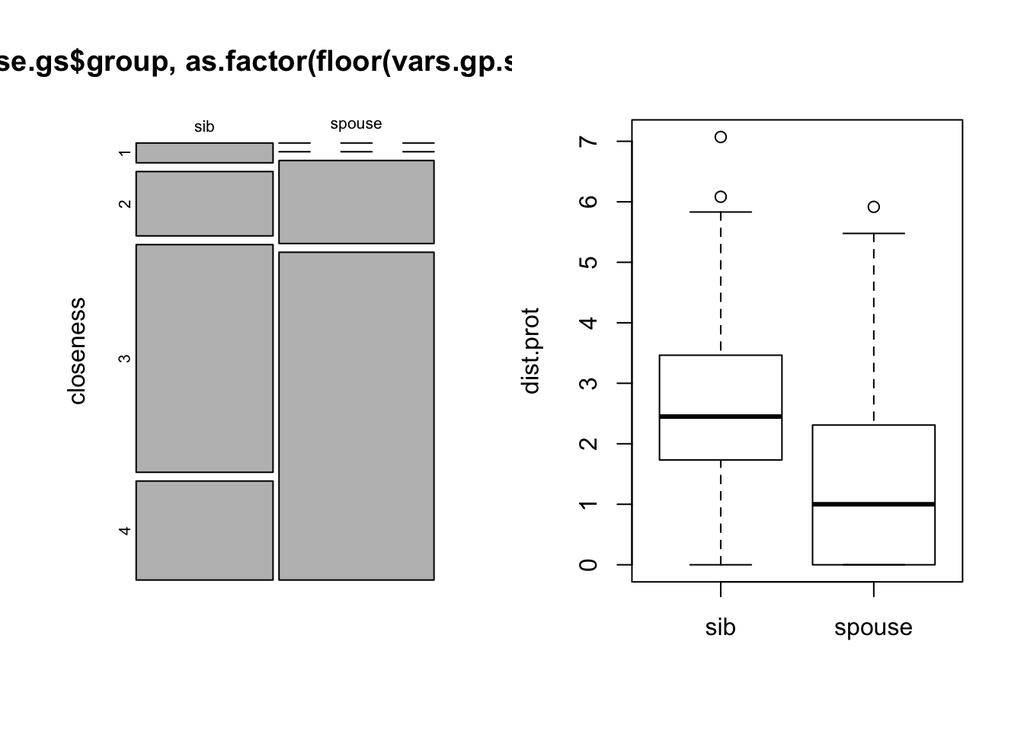

```r
#Plots
par(mfrow = c(1, 2))
plot(table(vars.gp.se.gs$group, as.factor(floor(vars.gp.se.gs$closeness))), ylab="closeness")
boxplot(match.prot.gp.se.gs ~ vars.gp.se.gs$group, ylab="dist.prot")
```

# OTUs and health

OTUs commonly shared between siblings or spouses (> 50% of pairs) and rare in the overall dataset (< 70% of samples, < 49% of unrelated pairs) were correlated to health outcomes in the whole dataset by Kruskal-Wallis with the Benjamini-Hochberg correction for multiple comparisons.

We will co-op the `kruskal.pretty` function to run these tests by creating a fake SIMPER output. We will also need to load our unaltered `.cons.taxonomy` table from mothur as the function cannot take the altered version `Tax` we have used those far.

```r
#Fake SIMPER output to get OTU list for health analyses
fake.simper = data.frame(
  X = c(1:22),
  Comparison = rep("1_2", 22),
  SIMPER = rep(0.001, 22),
  OTU = c("Otu00027","Otu00035","Otu00043","Otu00007","Otu00019","Otu00025","Otu00047","Otu00004","Otu00048","Otu00049","Otu00105","Otu00145","Otu00130","Otu00028","Otu00135","Otu00074","Otu00295","Otu00160","Otu00173","Otu00157","Otu00330","Otu00116")
)

#Unaltered mothur taxonomy table
Tax.orig = read.table("WLS.final.an.unique_list.0.02.cons.taxonomy", header=TRUE, row.names=1, sep="\t")
```

We then run Kruskal-Wallis tests for our health variables with NAs removed.

```r
kruskal.pretty(OTU[!is.na(Pheno.sm$hbp11),], Pheno.sm[!is.na(Pheno.sm$hbp11),], fake.simper, c("hbp11"), 'hbp', Tax.orig)
kruskal.pretty(OTU[!is.na(Pheno.sm$hbs11),], Pheno.sm[!is.na(Pheno.sm$hbs11),], fake.simper, c("hbs11"), 'hbs', Tax.orig)
kruskal.pretty(OTU[!is.na(Pheno.sm$heart11),], Pheno.sm[!is.na(Pheno.sm$heart11),], fake.simper, c("heart11"), 'heart', Tax.orig)
kruskal.pretty(OTU[!is.na(Pheno.sm$arth11),], Pheno.sm[!is.na(Pheno.sm$arth11),], fake.simper, c("arth11"), 'arth', Tax.orig)
kruskal.pretty(OTU[!is.na(Pheno.sm$cancer11),], Pheno.sm[!is.na(Pheno.sm$cancer11),], fake.simper, c("cancer11"), 'cancer', Tax.orig)
kruskal.pretty(OTU[!is.na(Pheno.sm$stroke11),], Pheno.sm[!is.na(Pheno.sm$stroke11),], fake.simper, c("stroke11"), 'stroke', Tax.orig)
```

The IBS variable was not part of the Pheno.sm survey so we curate it from the larger Pheno data set.

- jx148rer = graduates
- px148rer = siblings

```r
vars.IBS = data.frame(
  IBS = c(Pheno$jx148rer, Pheno$px148rer),
  ID = c(paste(Pheno$idpriv, "g", sep=""), paste(Pheno$idpriv, "s", sep="")),
  row.names = c(paste(Pheno$idpriv, "g", sep=""), paste(Pheno$idpriv, "s", sep=""))
)

#Subset to data with microbiota samples and IBS data
vars.IBS.sub = as.data.frame(subset(vars.IBS, row.names(vars.IBS) %in% row.names(OTU)))
vars.IBS.all = as.data.frame(vars.IBS.sub[!is.na(vars.IBS.sub$IBS),])
OTU.IBS = subset(OTU, row.names(OTU) %in% row.names(vars.IBS.all))
```

Run Kruskal-Wallis test of new IBS varibale.

```r
kruskal.pretty(OTU.IBS, vars.IBS.all, fake.simper, c("IBS"), 'IBS', Tax.orig)
```

# Figures

## Figure 1

```r
set.seed(51234)
#Calculate NMDS
uwUF.g.ordu = ordinate(physeq.tree.g, method="NMDS", distance="unifrac", weighted=FALSE)
```

```
## *** No convergence -- monoMDS stopping criteria:
##     20: stress ratio > sratmax
```

```r
#Create data set of just significant variables
vars.envfit = data.frame(
  AB = ifelse(vars.g$AB == "Y", 2, 1), #Reverse code so that arrow points toward Y responses
  cohabYN = ifelse(vars.g$cohabYN == "N", 1, 2),#Reverse code so that arrow points toward Y responses
  socialness = vars.g$social.sum,
  hbs = ifelse(vars.g$hbs11 == "Y", 2, 1),#Reverse code so that arrow points toward Y responses
  heart = ifelse(vars.g$heart11 == 1, 2, 1),#Reverse code so that arrow points toward Y responses
  meat = vars.g$meat,
  poultry = vars.g$poul,
  prot.sum = vars.g$prot.sum,
  social.cohabY = ifelse(vars.g$cohabYN == "Y", vars.g$social.sum, NA),
  social.cohabN = ifelse(vars.g$cohabYN == "N", vars.g$social.sum, NA),
  row.names = row.names(vars.g))


#Fit variables to NMDS
ef.uwUF.AB = envfit(uwUF.g.ordu ~ AB, data=vars.envfit, na.rm=TRUE)
```

[output not shown]

[output cut: 1942 more lines]

[output not shown]

```r
ef.uwUF.socY = envfit(uwUF.g.ordu ~ social.cohabY, data=vars.envfit, na.rm=TRUE)
ef.uwUF.socN = envfit(uwUF.g.ordu ~ social.cohabN, data=vars.envfit, na.rm=TRUE)
ef.uwUF.hbs = envfit(uwUF.g.ordu ~ hbs, data=vars.envfit, na.rm=TRUE)
```

[output not shown]

[output cut: 1944 more lines]

[output not shown]

```r
ef.uwUF.heart = envfit(uwUF.g.ordu ~ heart, data=vars.envfit, na.rm=TRUE)
ef.uwUF.meat = envfit(uwUF.g.ordu ~ meat, data=vars.envfit, na.rm=TRUE)
ef.uwUF.poul = envfit(uwUF.g.ordu ~ poultry, data=vars.envfit, na.rm=TRUE)

#Figure 1
postscript("FIGURE1.eps", width = 4.2, height = 4.5, horizontal = FALSE, onefile = FALSE, paper = "special", colormodel = "rgb", family = "ArialMT")
plot(uwUF.g.ordu, type="n", main="", xlab="", ylab="")
points(uwUF.g.ordu, pch=21, cex=0.75, display="sites", col="black", bg=c("red","blue")[as.factor(Pheno.sm.g$gender)])
plot(ef.uwUF.AB, col="red")
plot(ef.uwUF.socY, col="black")
plot(ef.uwUF.socN, col="red")
plot(ef.uwUF.hbs, col="red")
plot(ef.uwUF.heart, col="red")
plot(ef.uwUF.meat, col="black")
plot(ef.uwUF.poul, col="black")
dev.off()
```

## Figure 2

```r
#Figure 2
postscript("FIGURE2new.eps", width = 5, height = 4, horizontal = FALSE, onefile = FALSE, paper = "special", colormodel = "rgb", family = "ArialMT")
layout(matrix(c(1,2), 1, 2, byrow = TRUE), widths=c(1,1), heights=c(1,1))

#Shannon
boxplot(Met.g$shannon ~ vars.g$cohabYN, ylab="Shannon's diversity", main="", xlab="Cohabitating", col=c("red", "blue"))

#Chao
boxplot(Met.g$chao ~ vars.g$cohabYN, ylab="Chao's richness", main="", xlab="Cohabitating", col=c("red", "blue"))
dev.off()
```

## Figure 3

```r
#Load results from KW.subsample.fxn
KW.results.final = read.table("KW.results.csv", sep=",")

#Re-organize into data frame
gp.se.gs.boxplot = data.frame(
  BC = c(match.BC.gp.se.gs, KW.results.final[KW.results.final$V6 == "dist" & complete.cases(KW.results.final),]$V2),
  J = c(match.J.gp.se.gs, KW.results.final[KW.results.final$V6 == "dist" & complete.cases(KW.results.final),]$V3),
  wUF = c(match.wUF.gp.se.gs, KW.results.final[KW.results.final$V6 == "dist" & complete.cases(KW.results.final),]$V4),
  uwUF = c(match.uwUF.gp.se.gs, KW.results.final[KW.results.final$V6 == "dist" & complete.cases(KW.results.final),]$V5),
  group = c(rep("1.spouse", length(match.BC.gp.se)), rep("2.sibling", length(match.BC.gs)), rep("3.unrelated", length((KW.results.final[KW.results.final$V6 == "dist" & complete.cases(KW.results.final),]$V2)))))


#Add variable for closeness:pair type
vars.gp.se.gs$closeness.group = ifelse(floor(vars.gp.se.gs$closeness) == 1 & vars.gp.se.gs$group == "spouse", "1.spouse",
                                ifelse(floor(vars.gp.se.gs$closeness) == 2 & vars.gp.se.gs$group == "spouse", "2.spouse",
                                ifelse(floor(vars.gp.se.gs$closeness) == 3 & vars.gp.se.gs$group == "spouse", "3.spouse",
                                ifelse(floor(vars.gp.se.gs$closeness) == 4 & vars.gp.se.gs$group == "spouse", "4.spouse",
                                ifelse(floor(vars.gp.se.gs$closeness) == 1 & vars.gp.se.gs$group == "sib", "1.sib",
                                ifelse(floor(vars.gp.se.gs$closeness) == 2 & vars.gp.se.gs$group == "sib", "2.sib",
                                ifelse(floor(vars.gp.se.gs$closeness) == 3 & vars.gp.se.gs$group == "sib", "3.sib",
                                ifelse(floor(vars.gp.se.gs$closeness) == 4 & vars.gp.se.gs$group == "sib", "4.sib", floor(vars.gp.se.gs$closeness)))))))))

#Figure 3
postscript("FIGURE3.eps", width = 8, height = 5, horizontal = FALSE, onefile = FALSE, paper = "special", colormodel = "rgb", family = "ArialMT")
layout(matrix(c(1,2,3), 1, 3, byrow = TRUE), widths=c(2,2.5,3), heights=c(1,1,1))

boxplot(gp.se.gs.boxplot$uwUF ~ gp.se.gs.boxplot$group, main = "", ylab="Unweighted UniFrac distance", col=c("red","blue","white"), ylim=c(0.3,0.95))

boxplot(match.uwUF.gp.se.gs~floor(vars.gp.se.gs$closeness), xlab="", ylab="", main="",  outpch=NA, ylim=c(0.3,0.95), col="purple")

boxplot(match.uwUF.gp.se.gs~vars.gp.se.gs$closeness.group, col=c("blue", "blue", "blue", "red", "blue", "red"), xlab="", ylab="", main="",  outpch=NA, ylim=c(0.3,0.95))
dev.off()
```

## Figure 4

```r
#Calculate relative abundances
abund = OTU/rowSums(OTU)

#Re-code variable to YN letters
Pheno.sm$hbs = ifelse(Pheno.sm$hbs11 == 1, "Y", ifelse(Pheno.sm$hbs11 == 2, "N", Pheno.sm$hbs11))

#Combine OTU abundance with health data
hbs.OTUs1 = data.frame(
  abundance = c(abund$Otu00160*100,abund$Otu00295*100),
  OTU = c(rep("OTU160", 408),rep("OTU295", 408)),
  hbs = rep(Pheno.sm$hbs, 2))
hbs.OTUs2 = data.frame(
  abundance = c(abund$Otu00004*100,abund$Otu00019*100,abund$Otu00074*100),
  OTU = c(rep("OTU004", 408),rep("OTU019", 408),rep("OTU074", 408)),
  hbs = rep(Pheno.sm$hbs, 3))

#Calculate means and standard deviations of OTU abundances within health groups
hbs.OTUs.data1 = aggregate(hbs.OTUs1$abundance, by=list(hbs.OTUs1$OTU, hbs.OTUs1$hbs), FUN = function(x) c(mean = mean(x), sd = sd(x), n=length(x)))
hbs.OTUs.data1 = do.call(data.frame, hbs.OTUs.data1)
hbs.OTUs.data1$se = hbs.OTUs.data1$x.sd / sqrt(hbs.OTUs.data1$x.n)
colnames(hbs.OTUs.data1) = c("OTU", "hbs", "mean", "sd", "n", "se")

hbs.OTUs.data2 = aggregate(hbs.OTUs2$abundance, by=list(hbs.OTUs2$OTU, hbs.OTUs2$hbs), FUN = function(x) c(mean = mean(x), sd = sd(x), n=length(x)))
hbs.OTUs.data2 = do.call(data.frame, hbs.OTUs.data2)
hbs.OTUs.data2$se = hbs.OTUs.data2$x.sd / sqrt(hbs.OTUs.data2$x.n)
colnames(hbs.OTUs.data2) = c("OTU", "hbs", "mean", "sd", "n", "se")

#Figure 4
limits1 <- aes(ymax = hbs.OTUs.data1$mean + hbs.OTUs.data1$se, ymin = hbs.OTUs.data1$mean - hbs.OTUs.data1$se)
p1 = ggplot(data = hbs.OTUs.data1, aes(x = factor(OTU), y = mean, fill = factor(hbs)))
limits2 <- aes(ymax = hbs.OTUs.data2$mean + hbs.OTUs.data2$se, ymin = hbs.OTUs.data2$mean - hbs.OTUs.data2$se)
p2 = ggplot(data = hbs.OTUs.data2, aes(x = factor(OTU), y = mean, fill = factor(hbs)))
plot1 = p1 + geom_bar(stat = "identity", position = position_dodge(0.9)) +
  geom_errorbar(limits1, position = position_dodge(0.9),  width = 0.25) +
  labs(x = "", y = "Relative abundance (%)") + scale_fill_manual(name = "HBS", values=c("red", "blue")) +
  theme_bw() + theme(panel.border = element_blank(), panel.grid.major = element_blank(), panel.grid.minor = element_blank(), axis.line = element_line(colour = "black"), axis.text = element_text(colour="black"), axis.ticks = element_line(colour="black"))
plot2 = p2 + geom_bar(stat = "identity", position = position_dodge(0.9)) +
  geom_errorbar(limits2, position = position_dodge(0.9),  width = 0.25) +
  labs(x = "", y = "") + scale_fill_manual(name = "HBS", values=c("red", "blue")) +
  theme_bw() + theme(panel.border = element_blank(), panel.grid.major = element_blank(), panel.grid.minor = element_blank(), axis.line = element_line(colour = "black"), axis.text = element_text(colour="black"), axis.ticks = element_line(colour="black"))

postscript("FIGURE4.eps", width = 5, height = 2.5, horizontal = FALSE, onefile = FALSE, paper = "special", colormodel = "rgb", family = "ArialMT")
multiplot(plot1, plot2, cols=2)
dev.off()
```

## Figure S1

```r
set.seed(51234)
#Calculate NMDS
BC.g.MDS=metaMDS(OTU.g, distance="bray", k=2, trymax=500)
```

```
## Square root transformation
## Wisconsin double standardization
## *** Solution reached
```

```r
J.g.MDS=metaMDS(OTU.g, distance="jaccard", k=2, trymax=500)
```

```
## Square root transformation
## Wisconsin double standardization
## *** Solution reached
```

```r
wUF.g.ordu = ordinate(physeq.tree.g, method="NMDS", distance="unifrac", weighted=TRUE)
```

```
## *** No convergence -- monoMDS stopping criteria:
##     20: stress ratio > sratmax
```

```r
#Fit environmental variables
ef.BC.AB = envfit(BC.g.MDS ~ AB, data=vars.envfit, na.rm=TRUE)
```

[output not shown]

[output cut: 1942 more lines]

[output not shown]

```r
ef.BC.socY = envfit(BC.g.MDS ~ social.cohabY, data=vars.envfit, na.rm=TRUE)
ef.BC.socN = envfit(BC.g.MDS ~ social.cohabN, data=vars.envfit, na.rm=TRUE)
ef.BC.hbs = envfit(BC.g.MDS ~ hbs, data=vars.envfit, na.rm=TRUE)
```

[output not shown]

[output cut: 1944 more lines]

[output not shown]

```r
ef.BC.heart = envfit(BC.g.MDS ~ heart, data=vars.envfit, na.rm=TRUE)
ef.BC.prot = envfit(BC.g.MDS ~ prot.sum, data=vars.envfit, na.rm=TRUE)
ef.BC.meat = envfit(BC.g.MDS ~ meat, data=vars.envfit, na.rm=TRUE)
ef.BC.poul = envfit(BC.g.MDS ~ poultry, data=vars.envfit, na.rm=TRUE)

ef.J.AB = envfit(J.g.MDS ~ AB, data=vars.envfit, na.rm=TRUE)
```

[output not shown]

[output cut: 1944 more lines]

[output not shown]

```r
ef.J.cohab = envfit(J.g.MDS ~ cohabYN, data=vars.envfit, na.rm=TRUE)
ef.J.socY = envfit(J.g.MDS ~ social.cohabY, data=vars.envfit, na.rm=TRUE)
ef.J.socN = envfit(J.g.MDS ~ social.cohabN, data=vars.envfit, na.rm=TRUE)
ef.J.hbs = envfit(J.g.MDS ~ hbs, data=vars.envfit, na.rm=TRUE)
```

[output not shown]

[output cut: 1944 more lines]

[output not shown]

```r
ef.J.heart = envfit(J.g.MDS ~ heart, data=vars.envfit, na.rm=TRUE)
ef.J.prot = envfit(J.g.MDS ~ prot.sum, data=vars.envfit, na.rm=TRUE)
ef.J.meat = envfit(J.g.MDS ~ meat, data=vars.envfit, na.rm=TRUE)
ef.J.poul = envfit(J.g.MDS ~ poultry, data=vars.envfit, na.rm=TRUE)

ef.wUF.AB = envfit(wUF.g.ordu ~ AB, data=vars.envfit, na.rm=TRUE)
```

[output not shown]

[output cut: 1944 more lines]

[output not shown]

```r
ef.wUF.prot = envfit(wUF.g.ordu ~ prot.sum, data=vars.envfit, na.rm=TRUE)
ef.wUF.meat = envfit(wUF.g.ordu ~ meat, data=vars.envfit, na.rm=TRUE)
ef.wUF.poul = envfit(wUF.g.ordu ~ poultry, data=vars.envfit, na.rm=TRUE)

#Figure S1
postscript("FIGURES1.eps", width = 9, height = 3, horizontal = FALSE, onefile = FALSE, paper = "special", colormodel = "rgb", family = "ArialMT")
layout(matrix(c(1,2,3), 1, 3, byrow = TRUE), widths=c(1,1,1), heights=c(1,1,1))
plot(BC.g.MDS, type="n", main="Bray-Curtis", xlab="", ylab="")
  points(BC.g.MDS, pch=21, cex=0.75, display="sites", col="black", bg=c("red","blue")[as.factor(Pheno.sm.g$gender)])
  plot(ef.BC.AB, col="red")
  plot(ef.BC.hbs, col="red")
  plot(ef.BC.heart, col="red")
  plot(ef.BC.prot, col="black")
  plot(ef.BC.socY, col="black")
  plot(ef.BC.socN, col="black")
  plot(ef.BC.meat, col="black")
  plot(ef.BC.poul, col="black")
plot(J.g.MDS, type="n", main="Jaccard", xlab="", ylab="")
  points(J.g.MDS, pch=21, cex=0.75, display="sites", col="black", bg=c("red","blue")[as.factor(Pheno.sm.g$gender)])
  plot(ef.J.AB, col="red")
  plot(ef.J.cohab, col="black")
  plot(ef.J.socY, col="black")
  plot(ef.J.socN, col="black")
  plot(ef.J.hbs, col="black")
  plot(ef.J.heart, col="black")
  plot(ef.J.prot, col="black")
  plot(ef.J.meat, col="black")
  plot(ef.J.poul, col="black")
plot(wUF.g.ordu, type="n", main="Weighted UniFrac", xlab="", ylab="", xlim=c(-0.03,0.03), ylim=c(-0.03,0.03))
  points(wUF.g.ordu, pch=21, cex=0.75, display="sites", col="black", bg=c("red","blue")[as.factor(Pheno.sm.g$gender)])
  plot(ef.wUF.AB, col="black")
  plot(ef.wUF.prot, col="black")
  plot(ef.wUF.meat, col="black")
  plot(ef.wUF.poul, col="black")
dev.off()
```

## Figure S2

```r
#Re-code variables to YN letters
vars.g$AB = ifelse(vars.g$AB == 1, "Y", ifelse(vars.g$AB == 2, "N", vars.g$AB))
vars.g$hbs11 = ifelse(vars.g$hbs11 == 1, "Y", ifelse(vars.g$hbs11 == 2, "N", vars.g$hbs11))

#Figure S2ABCD
postscript("FIGURES2a.eps", width = 6, height = 6, horizontal = FALSE, onefile = FALSE, paper = "special", colormodel = "rgb", family = "ArialMT")
layout(matrix(c(1,2,3,4), 2, 2, byrow = TRUE), widths=c(1,1), heights=c(1,1))
#Shannon
boxplot(Met.g$shannon ~ vars.g$AB, ylab="Shannon's diversity", main="", xlab="Antibiotic use last 6mo")
  stripchart(Met.g$shannon ~ vars.g$AB, col="black", bg="black", pch=21, vertical=TRUE, method="jitter", add=TRUE, cex=0.25)
boxplot(Met.g$shannon ~ vars.g$hbs11, main="", xlab="High blood sugar")
  stripchart(Met.g$shannon ~ vars.g$hbs11, col="black", bg="black", pch=21, vertical=TRUE, method="jitter", add=TRUE, cex=0.25)
#Chao
boxplot(Met.g$chao ~ vars.g$RU57, ylab="Chao's richness", main="", xlab="1957")
  stripchart(Met.g$chao ~ vars.g$RU57, col="black", bg="black", pch=21, vertical=TRUE, method="jitter", add=TRUE, cex=0.25)
boxplot(Met.g$chao ~ vars.g$RU11, main="", xlab="2011")
  stripchart(Met.g$chao ~ vars.g$RU11, col="black", bg="black", pch=21, vertical=TRUE, method="jitter", add=TRUE, cex=0.25)
dev.off()
```

```r
#Figure S2E
postscript("FIGURES2b.eps", width = 3, height = 3, horizontal = FALSE, onefile = FALSE, paper = "special", colormodel = "rgb", family = "ArialMT")
layout(matrix(c(1), 1, 1, byrow = TRUE), widths=c(1), heights=c(1))
levelplot(Met.g$shannon ~ vars.g$poul*vars.g$meat, col.regions=function(x)rev(gray.colors(x)), xlab="Poultry (times per week)", ylab="Meat (times per week)", main="")
dev.off()
```

```r
#Figure S2F
postscript("FIGURES2c.eps", width = 3, height = 3, horizontal = FALSE, onefile = FALSE, paper = "special", colormodel = "rgb", family = "ArialMT")
layout(matrix(c(1), 1, 1, byrow = TRUE), widths=c(1), heights=c(1))
levelplot(Met.g$shannon ~ vars.g$poul*vars.g$pork, col.regions=function(x)rev(gray.colors(x)), xlab="Poultry (times per week)", ylab="Pork (times per week)", main="")
dev.off()
```

## Figure S3

```r
#Calculate linear models
shan.social.cohabY = glm(Met.g[vars.g$cohabYN == "Y",]$shannon ~ vars.g[vars.g$cohabYN == "Y",]$social.sum)
shan.social.cohabN = glm(Met.g[vars.g$cohabYN == "N",]$shannon ~ vars.g[vars.g$cohabYN == "N",]$social.sum)
chao.social.cohabY = glm(Met.g[vars.g$cohabYN == "Y",]$chao ~ vars.g[vars.g$cohabYN == "Y",]$social.sum)
chao.social.cohabN = glm(Met.g[vars.g$cohabYN == "N",]$chao ~ vars.g[vars.g$cohabYN == "N",]$social.sum)

#Figure S3
postscript("FIGURES3.eps", width = 6, height = 6, horizontal = FALSE, onefile = FALSE, paper = "special", colormodel = "rgb", family = "ArialMT")
layout(matrix(c(1,2,3,4), 2, 2, byrow = TRUE), widths=c(1,1), heights=c(1,1))

plot(Met.g$shannon ~ vars.g$social.sum, pch=21, col="black", bg=c("red","blue")[vars.g$cohabYN], ylab="", main="", xlab="Social interactions / 4 weeks", cex=0.75)
        abline(shan.social.cohabY, col="blue")
        abline(shan.social.cohabN, col="red")
#Chao
plot(Met.g$chao ~ vars.g$social.sum, pch=21, col="black", bg=c("red","blue")[vars.g$cohabYN], ylab="", main="", xlab="Social interactions / 4 weeks", cex=0.75)
        abline(chao.social.cohabY, col="blue")
        abline(chao.social.cohabN, col="red")
dev.off()
```

## Figure S4

```r
#Figure S4
postscript("FIGURES4.eps", width = 9, height = 9, horizontal = FALSE, onefile = FALSE, paper = "special", colormodel = "rgb", family = "ArialMT")
layout(matrix(c(1,2,3,4,5,6,7,8,9), 3, 3, byrow = TRUE), widths=c(1,1,1), heights=c(1,1,1))
#BC
boxplot(gp.se.gs.boxplot$BC ~ gp.se.gs.boxplot$group, main = "", ylab="Bray-Curtis distance", col=c("red","blue","white"), ylim=c(0.05,1))
boxplot(match.BC.gp.se.gs~floor(vars.gp.se.gs$closeness), xlab="", ylab="", main="",  outpch=NA, ylim=c(0.05,1), col="purple")
  stripchart(match.BC.gp.se.gs~floor(vars.gp.se.gs$closeness), col="black", bg="black", pch=21, vertical=TRUE, method="jitter", add=TRUE, cex=0.5)
boxplot(match.BC.gp.se.gs~vars.gp.se.gs$closeness.group, col=c("blue", "blue", "blue", "red", "blue", "red"), xlab="", ylab="", main="",  outpch=NA, ylim=c(0.05,1))
  stripchart(match.BC.gp.se.gs~vars.gp.se.gs$closeness.group, col="black", bg="black", pch=21, vertical=TRUE, method="jitter", add=TRUE, cex=0.5)
#J
boxplot(gp.se.gs.boxplot$J ~ gp.se.gs.boxplot$group, main = "", ylab="Jaccard distance", col=c("red","blue","white"), ylim=c(0.1,1))
boxplot(match.J.gp.se.gs~floor(vars.gp.se.gs$closeness), xlab="", ylab="", main="",  outpch=NA, ylim=c(0.1,1), col="purple")
  stripchart(match.J.gp.se.gs~floor(vars.gp.se.gs$closeness), col="black", bg="black", pch=21, vertical=TRUE, method="jitter", add=TRUE, cex=0.5)
boxplot(match.J.gp.se.gs~vars.gp.se.gs$closeness.group, col=c("blue", "blue", "blue", "red", "blue", "red"), xlab="", ylab="", main="",  outpch=NA, ylim=c(0.1,1))
  stripchart(match.J.gp.se.gs~vars.gp.se.gs$closeness.group, col="black", bg="black", pch=21, vertical=TRUE, method="jitter", add=TRUE, cex=0.5)
#wUF
boxplot(gp.se.gs.boxplot$wUF ~ gp.se.gs.boxplot$group, main = "", ylab="Weighted UniFrac distance", col=c("red","blue","white"), ylim=c(0.05,0.7))
boxplot(match.wUF.gp.se.gs~floor(vars.gp.se.gs$closeness), xlab="", ylab="", main="",  outpch=NA, ylim=c(0.05,0.7), col="purple")
  stripchart(match.wUF.gp.se.gs~floor(vars.gp.se.gs$closeness), col="black", bg="black", pch=21, vertical=TRUE, method="jitter", add=TRUE, cex=0.5)
boxplot(match.wUF.gp.se.gs~vars.gp.se.gs$closeness.group, col=c("blue", "blue", "blue", "red", "blue", "red"), xlab="", ylab="", main="",  outpch=NA, ylim=c(0.05,0.7))
  stripchart(match.wUF.gp.se.gs~vars.gp.se.gs$closeness.group, col="black", bg="black", pch=21, vertical=TRUE, method="jitter", add=TRUE, cex=0.5)
dev.off()
```

## Figure S5

```r
#Figure S5
postscript("FIGURES5.eps", width = 3, height = 3, horizontal = FALSE, onefile = FALSE, paper = "special", colormodel = "rgb", family = "ArialMT")
plot(match.uwUF.gp.se.gs ~ match.prot.gp.se.gs, bg=c(rep("red",94), rep("blue", 83)), col="black", pch=21, main = "", xlab="Euclidean distances of protein consumption", ylab = "Unweighted UniFrac distance", cex=0.5)
  uwUF.spouse = lm(match.uwUF.gp.se.gs[vars.gp.se.gs$group == "spouse"] ~ match.prot.gp.se.gs[vars.gp.se.gs$group == "spouse"])
    uwUF.sib = lm(match.uwUF.gp.se.gs[vars.gp.se.gs$group == "sib"] ~ match.prot.gp.se.gs[vars.gp.se.gs$group == "sib"])
    uwUF.all = lm(match.uwUF.gp.se.gs ~ match.prot.gp.se.gs)
    abline(uwUF.spouse, col="red")
    abline(uwUF.sib, col="blue")
    abline(uwUF.all, col="black")
dev.off()
```

## Figure S6

```r
#Figure S6A
postscript("FIGURES6a.eps", width = 3, height = 3, horizontal = FALSE, onefile = FALSE, paper = "special", colormodel = "rgb", family = "ArialMT")
boxplot(match.prot.gp.se.gs~vars.gp.se.gs$group, ylab="Euclidean distances of protein consumption", main="")
dev.off()
```

```r
#Figure S6B
postscript("FIGURES6b.eps", width = 3, height = 3, horizontal = FALSE, onefile = FALSE, paper = "special", colormodel = "rgb", family = "ArialMT")
plot(table(vars.gp.se.gs$group,floor(vars.gp.se.gs$closeness)), ylab="Closeness", main="")
dev.off()
```